# Amazon Analysis

```python
import numpy as np
import pandas as pd
import matplotlib.pyplot as plt
```

Does age or gender influence purchase frequency on Amazon?# 1.age= age 2.gender= gender 3.Purchase_Frequency= How frequently do you make purchases on Amazon? 4.Purchase_Categories= What product categories do you typically purchase on Amazon? 5.Personalized_Recommendation_Frequency = Have you ever made a purchase based on personalized product recommendations from Amazon? 6.Browsing_Frequency =How often do you browse Amazon's website or app? 7.Product_Search_Method =How do you search for products on Amazon? 8.Search_Result_Exploration =Do you tend to explore multiple pages of search results or focus on the first page? 9.Customer_Reviews_Importance =How important are customer reviews in your decision-making process? 10.Add_to_Cart_Browsing =Do you add products to your cart while browsing on Amazon? 11.Cart_Completion_Frequency =How often do you complete the purchase after adding products to your cart? 12.Cart_Abandonment_Factors =What factors influence your decision to abandon a purchase in your cart? 13.Saveforlater_Frequency =Do you use Amazon's "Save for Later" feature, and if so, how often? 14.Review_Left =Have you ever left a product review on Amazon? 15.Review_Reliability =How much do you rely on product reviews when making a purchase? 16.Review_Helpfulness =Do you find helpful information from other customers' reviews? 17.Personalized_Recommendation_Frequency =How often do you receive personalized product recommendations from Amazon? 18.Recommendation_Helpfulness =Do you find the recommendations helpful? 19.Rating_Accuracy =How would you rate the relevance and accuracy of the recommendations you receive 20.Shopping_Satisfaction =How satisfied are you with your overall shopping experience on Amazon? 23.Service_Appreciation =What aspects of Amazon's services do you appreciate the most? 24.Improvement_Areas =Are there any areas where you think Amazon can improve?

```python
data=pd.read_excel('Amazon Customer Behavior Survey.xlsx')
```

```python
data
```

|  | Timestamp | age | Gender | Purchase_Frequency | Purchase_Categories | Personalized_Recommendation_Frequency | Browsing_Frequency | Product_Search_Method | Search_Result_Exploration | Customer_Reviews_Importance | ... | Saveforlater_Frequency | Review_Left | Review_Reliability | Review_Helpfulness | Personalized_Recommendation_Frequency | Recommendation_Helpfulness | Rating_Accuracy | Shopping_Satisfaction | Service_Appreciation | Improvement_Areas |
| --- | --- | --- | --- | --- | --- | --- | --- | --- | --- | --- | --- | --- | --- | --- | --- | --- | --- | --- | --- | --- | --- |
| 0 | 2023/06/04 1:28:19 PM GMT+5:30 | 23 | Female | Few times a month | Beauty and Personal Care | Yes | Few times a week | Keyword | Multiple pages | 1 | ... | Sometimes | Yes | Occasionally | Yes | 2 | Yes | 1 | 1 | Competitive prices | Reducing packaging waste |
| 1 | 2023/06/04 2:30:44 PM GMT+5:30 | 23 | Female | Once a month | Clothing and Fashion | Yes | Few times a month | Keyword | Multiple pages | 1 | ... | Rarely | No | Heavily | Yes | 2 | Sometimes | 3 | 2 | Wide product selection | Reducing packaging waste |
| 2 | 2023/06/04 5:04:56 PM GMT+5:30 | 24 | Prefer not to say | Few times a month | Groceries and Gourmet Food;Clothing and Fashion | No | Few times a month | Keyword | Multiple pages | 2 | ... | Rarely | No | Occasionally | No | 4 | No | 3 | 3 | Competitive prices | Product quality and accuracy |
| 3 | 2023/06/04 5:13:00 PM GMT+5:30 | 24 | Female | Once a month | Beauty and Personal Care;Clothing and Fashion;... | Sometimes | Few times a month | Keyword | First page | 5 | ... | Sometimes | Yes | Heavily | Yes | 3 | Sometimes | 3 | 4 | Competitive prices | Product quality and accuracy |
| 4 | 2023/06/04 5:28:06 PM GMT+5:30 | 22 | Female | Less than once a month | Beauty and Personal Care;Clothing and Fashion | Yes | Few times a month | Filter | Multiple pages | 1 | ... | Rarely | No | Heavily | Yes | 4 | Yes | 2 | 2 | Competitive prices | Product quality and accuracy |
| ... | ... | ... | ... | ... | ... | ... | ... | ... | ... | ... | ... | ... | ... | ... | ... | ... | ... | ... | ... | ... | ... |
| 597 | 2023/06/12 4:02:02 PM GMT+5:30 | 23 | Female | Once a week | Beauty and Personal Care | Sometimes | Few times a week | categories | Multiple pages | 4 | ... | Sometimes | Yes | Moderately | Sometimes | 3 | Sometimes | 3 | 4 | Competitive prices | Customer service responsiveness |
| 598 | 2023/06/12 4:02:53 PM GMT+5:30 | 23 | Female | Once a week | Clothing and Fashion | Sometimes | Few times a week | Filter | Multiple pages | 3 | ... | Sometimes | Yes | Heavily | Sometimes | 3 | Sometimes | 3 | 3 | Product recommendations | Reducing packaging waste |
| 599 | 2023/06/12 4:03:59 PM GMT+5:30 | 23 | Female | Once a month | Beauty and Personal Care | Sometimes | Few times a week | categories | Multiple pages | 3 | ... | Sometimes | Yes | Occasionally | Sometimes | 3 | Sometimes | 2 | 3 | Wide product selection | Product quality and accuracy |
| 600 | 2023/06/12 9:57:20 PM GMT+5:30 | 23 | Female | Few times a month | Beauty and Personal Care;Clothing and Fashion;... | Yes | Few times a month | Keyword | Multiple pages | 1 | ... | Sometimes | No | Heavily | Yes | 2 | Yes | 2 | 2 | Wide product selection | Product quality and accuracy |
| 601 | 2023/06/16 9:16:05 AM GMT+5:30 | 23 | Female | Once a week | Clothing and Fashion | Sometimes | Multiple times a day | Keyword | Multiple pages | 3 | ... | Sometimes | Yes | Moderately | Sometimes | 3 | Sometimes | 3 | 3 | Product recommendations | Product quality and accuracy |

602 rows × 23 columns

```python
data.head(2)
```

|  | Timestamp | age | Gender | Purchase_Frequency | Purchase_Categories | Personalized_Recommendation_Frequency | Browsing_Frequency | Product_Search_Method | Search_Result_Exploration | Customer_Reviews_Importance | ... | Saveforlater_Frequency | Review_Left | Review_Reliability | Review_Helpfulness | Personalized_Recommendation_Frequency | Recommendation_Helpfulness | Rating_Accuracy | Shopping_Satisfaction | Service_Appreciation | Improvement_Areas |
| --- | --- | --- | --- | --- | --- | --- | --- | --- | --- | --- | --- | --- | --- | --- | --- | --- | --- | --- | --- | --- | --- |
| 0 | 2023/06/04 1:28:19 PM GMT+5:30 | 23 | Female | Few times a month | Beauty and Personal Care | Yes | Few times a week | Keyword | Multiple pages | 1 | ... | Sometimes | Yes | Occasionally | Yes | 2 | Yes | 1 | 1 | Competitive prices | Reducing packaging waste |
| 1 | 2023/06/04 2:30:44 PM GMT+5:30 | 23 | Female | Once a month | Clothing and Fashion | Yes | Few times a month | Keyword | Multiple pages | 1 | ... | Rarely | No | Heavily | Yes | 2 | Sometimes | 3 | 2 | Wide product selection | Reducing packaging waste |

2 rows × 23 columns

```python
data.isnull().sum()
```

```
Timestamp                                 0
age                                       0
Gender                                    0
Purchase_Frequency                        0
Purchase_Categories                       0
Personalized_Recommendation_Frequency     0
Browsing_Frequency                        0
Product_Search_Method                     2
Search_Result_Exploration                 0
Customer_Reviews_Importance               0
Add_to_Cart_Browsing                      0
Cart_Completion_Frequency                 0
Cart_Abandonment_Factors                  0
Saveforlater_Frequency                    0
Review_Left                               0
Review_Reliability                        0
Review_Helpfulness                        0
Personalized_Recommendation_Frequency     0
Recommendation_Helpfulness                0
Rating_Accuracy                           0
Shopping_Satisfaction                     0
Service_Appreciation                      0
Improvement_Areas                         0
dtype: int64
```

```python
data.dropna(inplace=True)
```

```python
data.isnull().sum()
```

```
Timestamp                                 0
age                                       0
Gender                                    0
Purchase_Frequency                        0
Purchase_Categories                       0
Personalized_Recommendation_Frequency     0
Browsing_Frequency                        0
Product_Search_Method                     0
Search_Result_Exploration                 0
Customer_Reviews_Importance               0
Add_to_Cart_Browsing                      0
Cart_Completion_Frequency                 0
Cart_Abandonment_Factors                  0
Saveforlater_Frequency                    0
Review_Left                               0
Review_Reliability                        0
Review_Helpfulness                        0
Personalized_Recommendation_Frequency     0
Recommendation_Helpfulness                0
Rating_Accuracy                           0
Shopping_Satisfaction                     0
Service_Appreciation                      0
Improvement_Areas                         0
dtype: int64
```

# filter Female Related Data

```python
Female=data[data['Gender']=='Female']
```

```python
Female
```

|  | Timestamp | age | Gender | Purchase_Frequency | Purchase_Categories | Personalized_Recommendation_Frequency | Browsing_Frequency | Product_Search_Method | Search_Result_Exploration | Customer_Reviews_Importance | ... | Saveforlater_Frequency | Review_Left | Review_Reliability | Review_Helpfulness | Personalized_Recommendation_Frequency | Recommendation_Helpfulness | Rating_Accuracy | Shopping_Satisfaction | Service_Appreciation | Improvement_Areas |
| --- | --- | --- | --- | --- | --- | --- | --- | --- | --- | --- | --- | --- | --- | --- | --- | --- | --- | --- | --- | --- | --- |
| 0 | 2023/06/04 1:28:19 PM GMT+5:30 | 23 | Female | Few times a month | Beauty and Personal Care | Yes | Few times a week | Keyword | Multiple pages | 1 | ... | Sometimes | Yes | Occasionally | Yes | 2 | Yes | 1 | 1 | Competitive prices | Reducing packaging waste |
| 1 | 2023/06/04 2:30:44 PM GMT+5:30 | 23 | Female | Once a month | Clothing and Fashion | Yes | Few times a month | Keyword | Multiple pages | 1 | ... | Rarely | No | Heavily | Yes | 2 | Sometimes | 3 | 2 | Wide product selection | Reducing packaging waste |
| 3 | 2023/06/04 5:13:00 PM GMT+5:30 | 24 | Female | Once a month | Beauty and Personal Care;Clothing and Fashion;... | Sometimes | Few times a month | Keyword | First page | 5 | ... | Sometimes | Yes | Heavily | Yes | 3 | Sometimes | 3 | 4 | Competitive prices | Product quality and accuracy |
| 4 | 2023/06/04 5:28:06 PM GMT+5:30 | 22 | Female | Less than once a month | Beauty and Personal Care;Clothing and Fashion | Yes | Few times a month | Filter | Multiple pages | 1 | ... | Rarely | No | Heavily | Yes | 4 | Yes | 2 | 2 | Competitive prices | Product quality and accuracy |
| 5 | 2023/06/04 6:01:59 PM GMT+5:30 | 21 | Female | Less than once a month | Clothing and Fashion | No | Rarely | categories | Multiple pages | 1 | ... | Never | No | Heavily | Yes | 5 | No | 5 | 2 | Wide product selection | Product quality and accuracy |
| ... | ... | ... | ... | ... | ... | ... | ... | ... | ... | ... | ... | ... | ... | ... | ... | ... | ... | ... | ... | ... | ... |
| 597 | 2023/06/12 4:02:02 PM GMT+5:30 | 23 | Female | Once a week | Beauty and Personal Care | Sometimes | Few times a week | categories | Multiple pages | 4 | ... | Sometimes | Yes | Moderately | Sometimes | 3 | Sometimes | 3 | 4 | Competitive prices | Customer service responsiveness |
| 598 | 2023/06/12 4:02:53 PM GMT+5:30 | 23 | Female | Once a week | Clothing and Fashion | Sometimes | Few times a week | Filter | Multiple pages | 3 | ... | Sometimes | Yes | Heavily | Sometimes | 3 | Sometimes | 3 | 3 | Product recommendations | Reducing packaging waste |
| 599 | 2023/06/12 4:03:59 PM GMT+5:30 | 23 | Female | Once a month | Beauty and Personal Care | Sometimes | Few times a week | categories | Multiple pages | 3 | ... | Sometimes | Yes | Occasionally | Sometimes | 3 | Sometimes | 2 | 3 | Wide product selection | Product quality and accuracy |
| 600 | 2023/06/12 9:57:20 PM GMT+5:30 | 23 | Female | Few times a month | Beauty and Personal Care;Clothing and Fashion;... | Yes | Few times a month | Keyword | Multiple pages | 1 | ... | Sometimes | No | Heavily | Yes | 2 | Yes | 2 | 2 | Wide product selection | Product quality and accuracy |
| 601 | 2023/06/16 9:16:05 AM GMT+5:30 | 23 | Female | Once a week | Clothing and Fashion | Sometimes | Multiple times a day | Keyword | Multiple pages | 3 | ... | Sometimes | Yes | Moderately | Sometimes | 3 | Sometimes | 3 | 3 | Product recommendations | Product quality and accuracy |

350 rows × 23 columns

```python
Female1=Female.iloc[1:100]
```

```python
Female2=Female.iloc[100:200]
```

```python
Female3=Female.iloc[200:350]
```

```python
Female1
```

|  | Timestamp | age | Gender | Purchase_Frequency | Purchase_Categories | Personalized_Recommendation_Frequency | Browsing_Frequency | Product_Search_Method | Search_Result_Exploration | Customer_Reviews_Importance | ... | Saveforlater_Frequency | Review_Left | Review_Reliability | Review_Helpfulness | Personalized_Recommendation_Frequency | Recommendation_Helpfulness | Rating_Accuracy | Shopping_Satisfaction | Service_Appreciation | Improvement_Areas |
| --- | --- | --- | --- | --- | --- | --- | --- | --- | --- | --- | --- | --- | --- | --- | --- | --- | --- | --- | --- | --- | --- |
| 1 | 2023/06/04 2:30:44 PM GMT+5:30 | 23 | Female | Once a month | Clothing and Fashion | Yes | Few times a month | Keyword | Multiple pages | 1 | ... | Rarely | No | Heavily | Yes | 2 | Sometimes | 3 | 2 | Wide product selection | Reducing packaging waste |
| 3 | 2023/06/04 5:13:00 PM GMT+5:30 | 24 | Female | Once a month | Beauty and Personal Care;Clothing and Fashion;... | Sometimes | Few times a month | Keyword | First page | 5 | ... | Sometimes | Yes | Heavily | Yes | 3 | Sometimes | 3 | 4 | Competitive prices | Product quality and accuracy |
| 4 | 2023/06/04 5:28:06 PM GMT+5:30 | 22 | Female | Less than once a month | Beauty and Personal Care;Clothing and Fashion | Yes | Few times a month | Filter | Multiple pages | 1 | ... | Rarely | No | Heavily | Yes | 4 | Yes | 2 | 2 | Competitive prices | Product quality and accuracy |
| 5 | 2023/06/04 6:01:59 PM GMT+5:30 | 21 | Female | Less than once a month | Clothing and Fashion | No | Rarely | categories | Multiple pages | 1 | ... | Never | No | Heavily | Yes | 5 | No | 5 | 2 | Wide product selection | Product quality and accuracy |
| 6 | 2023/06/04 6:31:41 PM GMT+5:30 | 22 | Female | Less than once a month | Clothing and Fashion | No | Rarely | Filter | Multiple pages | 1 | ... | Rarely | No | Heavily | Yes | 3 | Sometimes | 3 | 3 | Wide product selection | Shipping speed and reliability |
| ... | ... | ... | ... | ... | ... | ... | ... | ... | ... | ... | ... | ... | ... | ... | ... | ... | ... | ... | ... | ... | ... |
| 153 | 2023/06/06 7:02:21 PM GMT+5:30 | 26 | Female | Few times a month | Beauty and Personal Care;Clothing and Fashion | Yes | Few times a week | categories | Multiple pages | 1 | ... | Always | Yes | Occasionally | Yes | 5 | Yes | 1 | 1 | Wide product selection | Product quality and accuracy |
| 157 | 2023/06/06 7:11:13 PM GMT+5:30 | 33 | Female | Few times a month | Groceries and Gourmet Food;Beauty and Personal... | No | Few times a week | Filter | Multiple pages | 2 | ... | Often | No | Occasionally | No | 2 | No | 2 | 2 | Competitive prices | Reducing packaging waste |
| 158 | 2023/06/06 7:11:46 PM GMT+5:30 | 33 | Female | Once a week | Beauty and Personal Care;others | No | Few times a week | Filter | First page | 5 | ... | Rarely | No | Occasionally | No | 2 | Yes | 1 | 1 | Product recommendations | Shipping speed and reliability |
| 163 | 2023/06/06 7:18:01 PM GMT+5:30 | 60 | Female | Once a week | Beauty and Personal Care;Clothing and Fashion | Yes | Multiple times a day | Keyword | First page | 2 | ... | Sometimes | No | Occasionally | No | 2 | No | 2 | 3 | Product recommendations | Customer service responsiveness |
| 164 | 2023/06/06 7:18:52 PM GMT+5:30 | 18 | Female | Once a week | Groceries and Gourmet Food;Beauty and Personal... | No | Few times a month | categories | First page | 3 | ... | Often | No | Rarely | No | 4 | No | 4 | 4 | Competitive prices | Reducing packaging waste |

99 rows × 23 columns

```python
Female2
```

|  | Timestamp | age | Gender | Purchase_Frequency | Purchase_Categories | Personalized_Recommendation_Frequency | Browsing_Frequency | Product_Search_Method | Search_Result_Exploration | Customer_Reviews_Importance | ... | Saveforlater_Frequency | Review_Left | Review_Reliability | Review_Helpfulness | Personalized_Recommendation_Frequency | Recommendation_Helpfulness | Rating_Accuracy | Shopping_Satisfaction | Service_Appreciation | Improvement_Areas |
| --- | --- | --- | --- | --- | --- | --- | --- | --- | --- | --- | --- | --- | --- | --- | --- | --- | --- | --- | --- | --- | --- |
| 167 | 2023/06/06 7:21:26 PM GMT+5:30 | 19 | Female | Few times a month | Beauty and Personal Care;Clothing and Fashion | No | Few times a month | categories | First page | 3 | ... | Sometimes | No | Occasionally | No | 2 | No | 3 | 2 | Wide product selection | Customer service responsiveness |
| 168 | 2023/06/06 7:22:31 PM GMT+5:30 | 18 | Female | Once a month | Beauty and Personal Care;Clothing and Fashion;... | No | Rarely | others | First page | 4 | ... | Always | Yes | Moderately | No | 1 | No | 2 | 1 | Wide product selection | Product quality and accuracy |
| 170 | 2023/06/06 7:31:34 PM GMT+5:30 | 27 | Female | Once a month | Beauty and Personal Care | No | Few times a week | Keyword | Multiple pages | 1 | ... | Sometimes | Yes | Heavily | Yes | 3 | Sometimes | 3 | 2 | Wide product selection | Shipping speed and reliability |
| 172 | 2023/06/06 7:40:11 PM GMT+5:30 | 35 | Female | Few times a month | Beauty and Personal Care | No | Few times a month | categories | First page | 3 | ... | Often | Yes | Occasionally | No | 2 | No | 4 | 2 | Product recommendations | Reducing packaging waste |
| 173 | 2023/06/06 7:40:53 PM GMT+5:30 | 57 | Female | Few times a month | Groceries and Gourmet Food;Beauty and Personal... | No | Few times a week | Filter | Multiple pages | 2 | ... | Rarely | No | Occasionally | Yes | 3 | Sometimes | 3 | 1 | Product recommendations | Reducing packaging waste |
| ... | ... | ... | ... | ... | ... | ... | ... | ... | ... | ... | ... | ... | ... | ... | ... | ... | ... | ... | ... | ... | ... |
| 323 | 2023/06/08 12:22:05 PM GMT+5:30 | 18 | Female | Once a month | Clothing and Fashion | No | Few times a month | Keyword | Multiple pages | 2 | ... | Always | Yes | Heavily | Yes | 1 | Yes | 5 | 3 | User-friendly website/app interface | Shipping speed and reliability |
| 324 | 2023/06/08 2:21:41 PM GMT+5:30 | 26 | Female | Once a week | Beauty and Personal Care | Yes | Few times a month | categories | Multiple pages | 1 | ... | Sometimes | Yes | Moderately | Yes | 1 | Yes | 1 | 1 | Wide product selection | Product quality and accuracy |
| 325 | 2023/06/08 4:29:56 PM GMT+5:30 | 16 | Female | Less than once a month | Clothing and Fashion;Home and Kitchen | No | Few times a month | Keyword | Multiple pages | 1 | ... | Rarely | Yes | Heavily | Sometimes | 1 | Sometimes | 3 | 3 | Wide product selection | Product quality and accuracy |
| 328 | 2023/06/08 5:07:35 PM GMT+5:30 | 19 | Female | Few times a month | Beauty and Personal Care;Clothing and Fashion | Yes | Multiple times a day | Keyword | Multiple pages | 1 | ... | Often | Yes | Heavily | Yes | 1 | Yes | 1 | 1 | Wide product selection | Customer service responsiveness |
| 332 | 2023/06/08 5:13:33 PM GMT+5:30 | 22 | Female | Once a month | Beauty and Personal Care;Clothing and Fashion;... | Sometimes | Multiple times a day | Keyword | Multiple pages | 1 | ... | Sometimes | Yes | Moderately | Yes | 1 | Sometimes | 2 | 1 | Competitive prices | Product quality and accuracy |

100 rows × 23 columns

```python
Female3
```

|  | Timestamp | age | Gender | Purchase_Frequency | Purchase_Categories | Personalized_Recommendation_Frequency | Browsing_Frequency | Product_Search_Method | Search_Result_Exploration | Customer_Reviews_Importance | ... | Saveforlater_Frequency | Review_Left | Review_Reliability | Review_Helpfulness | Personalized_Recommendation_Frequency | Recommendation_Helpfulness | Rating_Accuracy | Shopping_Satisfaction | Service_Appreciation | Improvement_Areas |
| --- | --- | --- | --- | --- | --- | --- | --- | --- | --- | --- | --- | --- | --- | --- | --- | --- | --- | --- | --- | --- | --- |
| 337 | 2023/06/08 5:19:23 PM GMT+5:30 | 31 | Female | Few times a month | Clothing and Fashion;Home and Kitchen | Sometimes | Few times a week | categories | Multiple pages | 3 | ... | Often | No | Moderately | No | 2 | No | 2 | 2 | Competitive prices | Shipping speed and reliability |
| 339 | 2023/06/08 5:19:56 PM GMT+5:30 | 26 | Female | Once a month | Clothing and Fashion | No | Few times a week | categories | Multiple pages | 1 | ... | Often | Yes | Moderately | Yes | 1 | Yes | 1 | 3 | User-friendly website/app interface | Product quality and accuracy |
| 342 | 2023/06/08 5:22:08 PM GMT+5:30 | 26 | Female | Once a month | Beauty and Personal Care;Clothing and Fashion;... | No | Few times a week | categories | Multiple pages | 3 | ... | Rarely | No | Rarely | Sometimes | 4 | No | 4 | 3 | Competitive prices | Customer service responsiveness |
| 346 | 2023/06/08 5:25:27 PM GMT+5:30 | 31 | Female | Once a month | Groceries and Gourmet Food;Beauty and Personal... | Yes | Few times a week | Keyword | Multiple pages | 1 | ... | Often | No | Heavily | Yes | 2 | Sometimes | 3 | 1 | Competitive prices | Customer service responsiveness |
| 353 | 2023/06/08 5:30:34 PM GMT+5:30 | 47 | Female | Once a month | Groceries and Gourmet Food;Beauty and Personal... | Yes | Multiple times a day | Keyword | Multiple pages | 3 | ... | Sometimes | Yes | Occasionally | Sometimes | 2 | Sometimes | 3 | 2 | Competitive prices | Customer service responsiveness |
| ... | ... | ... | ... | ... | ... | ... | ... | ... | ... | ... | ... | ... | ... | ... | ... | ... | ... | ... | ... | ... | ... |
| 597 | 2023/06/12 4:02:02 PM GMT+5:30 | 23 | Female | Once a week | Beauty and Personal Care | Sometimes | Few times a week | categories | Multiple pages | 4 | ... | Sometimes | Yes | Moderately | Sometimes | 3 | Sometimes | 3 | 4 | Competitive prices | Customer service responsiveness |
| 598 | 2023/06/12 4:02:53 PM GMT+5:30 | 23 | Female | Once a week | Clothing and Fashion | Sometimes | Few times a week | Filter | Multiple pages | 3 | ... | Sometimes | Yes | Heavily | Sometimes | 3 | Sometimes | 3 | 3 | Product recommendations | Reducing packaging waste |
| 599 | 2023/06/12 4:03:59 PM GMT+5:30 | 23 | Female | Once a month | Beauty and Personal Care | Sometimes | Few times a week | categories | Multiple pages | 3 | ... | Sometimes | Yes | Occasionally | Sometimes | 3 | Sometimes | 2 | 3 | Wide product selection | Product quality and accuracy |
| 600 | 2023/06/12 9:57:20 PM GMT+5:30 | 23 | Female | Few times a month | Beauty and Personal Care;Clothing and Fashion;... | Yes | Few times a month | Keyword | Multiple pages | 1 | ... | Sometimes | No | Heavily | Yes | 2 | Yes | 2 | 2 | Wide product selection | Product quality and accuracy |
| 601 | 2023/06/16 9:16:05 AM GMT+5:30 | 23 | Female | Once a week | Clothing and Fashion | Sometimes | Multiple times a day | Keyword | Multiple pages | 3 | ... | Sometimes | Yes | Moderately | Sometimes | 3 | Sometimes | 3 | 3 | Product recommendations | Product quality and accuracy |

150 rows × 23 columns

# Age and Preferences for Female

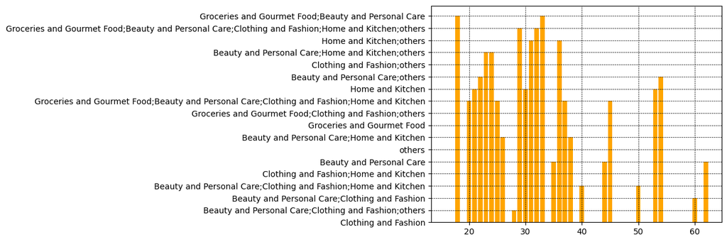

```python
plt.bar(Female1['age'],Female1['Purchase_Categories'],color='Orange')
plt.grid(True,linestyle='--',color='black',linewidth=0.5)
```

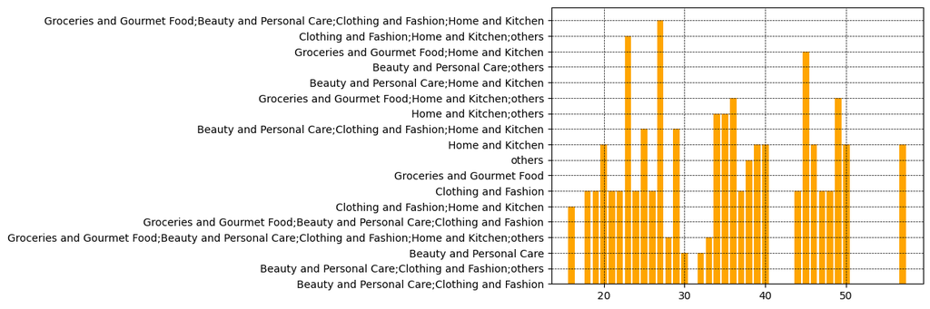

```python
plt.bar(Female2['age'],Female2['Purchase_Categories'],color='Orange')
plt.grid(True,linestyle='--',color='black',linewidth=0.5)
```

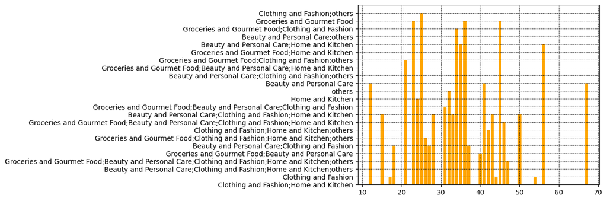

```python
plt.bar(Female3['age'],Female3['Purchase_Categories'],color='Orange')
plt.grid(True,linestyle='--',color='black',linewidth=0.5)
```

# Age and Preferences for male

```python
male=data[data['Gender']=='Male']
```

```python
male
```

|  | Timestamp | age | Gender | Purchase_Frequency | Purchase_Categories | Personalized_Recommendation_Frequency | Browsing_Frequency | Product_Search_Method | Search_Result_Exploration | Customer_Reviews_Importance | ... | Saveforlater_Frequency | Review_Left | Review_Reliability | Review_Helpfulness | Personalized_Recommendation_Frequency | Recommendation_Helpfulness | Rating_Accuracy | Shopping_Satisfaction | Service_Appreciation | Improvement_Areas |
| --- | --- | --- | --- | --- | --- | --- | --- | --- | --- | --- | --- | --- | --- | --- | --- | --- | --- | --- | --- | --- | --- |
| 16 | 2023/06/04 8:39:53 PM GMT+5:30 | 16 | Male | Few times a month | Clothing and Fashion;others | Sometimes | Few times a month | Keyword | Multiple pages | 1 | ... | Never | No | Heavily | Yes | 3 | Sometimes | 3 | 2 | Wide product selection | Shipping speed and reliability |
| 20 | 2023/06/04 8:49:49 PM GMT+5:30 | 64 | Male | Once a week | Groceries and Gourmet Food | No | Few times a month | Keyword | Multiple pages | 3 | ... | Never | No | Occasionally | Yes | 2 | Yes | 1 | 2 | Competitive prices | Reducing packaging waste |
| 22 | 2023/06/04 8:54:36 PM GMT+5:30 | 21 | Male | Less than once a month | others | No | Few times a week | others | Multiple pages | 1 | ... | Never | No | Never | Sometimes | 3 | Sometimes | 3 | 3 | . | . |
| 34 | 2023/06/04 11:12:15 PM GMT+5:30 | 23 | Male | Multiple times a week | Groceries and Gourmet Food;Beauty and Personal... | Yes | Few times a week | Keyword | Multiple pages | 1 | ... | Rarely | Yes | Heavily | Yes | 3 | Yes | 1 | 1 | Competitive prices | Customer service responsiveness |
| 38 | 2023/06/04 11:57:10 PM GMT+5:30 | 29 | Male | Once a month | Clothing and Fashion | Sometimes | Few times a week | categories | Multiple pages | 1 | ... | Often | No | Moderately | Yes | 2 | Yes | 2 | 2 | Competitive prices | Customer service responsiveness |
| ... | ... | ... | ... | ... | ... | ... | ... | ... | ... | ... | ... | ... | ... | ... | ... | ... | ... | ... | ... | ... | ... |
| 562 | 2023/06/11 11:27:25 PM GMT+5:30 | 21 | Male | Once a week | Clothing and Fashion | Sometimes | Few times a week | categories | Multiple pages | 1 | ... | Sometimes | No | Occasionally | Sometimes | 4 | Sometimes | 3 | 2 | Competitive prices | Customer service responsiveness |
| 563 | 2023/06/11 11:27:55 PM GMT+5:30 | 34 | Male | Less than once a month | Clothing and Fashion | No | Few times a week | categories | First page | 2 | ... | Sometimes | Yes | Occasionally | No | 2 | No | 3 | 3 | User-friendly website/app interface | Customer service responsiveness |
| 574 | 2023/06/12 3:27:59 PM GMT+5:30 | 60 | Male | Once a week | Beauty and Personal Care | Sometimes | Few times a month | Filter | Multiple pages | 3 | ... | Sometimes | Yes | Heavily | Sometimes | 3 | Sometimes | 3 | 3 | Product recommendations | Customer service responsiveness |
| 575 | 2023/06/12 3:29:20 PM GMT+5:30 | 26 | Male | Few times a month | Groceries and Gourmet Food | Sometimes | Few times a week | categories | Multiple pages | 4 | ... | Sometimes | Yes | Occasionally | Sometimes | 3 | Sometimes | 3 | 3 | Wide product selection | Customer service responsiveness |
| 586 | 2023/06/12 3:49:27 PM GMT+5:30 | 25 | Male | Multiple times a week | Beauty and Personal Care | Sometimes | Few times a week | categories | Multiple pages | 2 | ... | Always | Yes | Moderately | Sometimes | 3 | Sometimes | 3 | 2 | Product recommendations | Product quality and accuracy |

142 rows × 23 columns

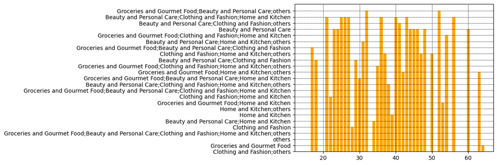

```python
plt.bar(male['age'],male['Purchase_Categories'],color='Orange')
plt.grid(True,linestyle='--',color='black',linewidth=0.5)
```

```python
data.head(2)
```

|  | Timestamp | age | Gender | Purchase_Frequency | Purchase_Categories | Personalized_Recommendation_Frequency | Browsing_Frequency | Product_Search_Method | Search_Result_Exploration | Customer_Reviews_Importance | ... | Saveforlater_Frequency | Review_Left | Review_Reliability | Review_Helpfulness | Personalized_Recommendation_Frequency | Recommendation_Helpfulness | Rating_Accuracy | Shopping_Satisfaction | Service_Appreciation | Improvement_Areas |
| --- | --- | --- | --- | --- | --- | --- | --- | --- | --- | --- | --- | --- | --- | --- | --- | --- | --- | --- | --- | --- | --- |
| 0 | 2023/06/04 1:28:19 PM GMT+5:30 | 23 | Female | Few times a month | Beauty and Personal Care | Yes | Few times a week | Keyword | Multiple pages | 1 | ... | Sometimes | Yes | Occasionally | Yes | 2 | Yes | 1 | 1 | Competitive prices | Reducing packaging waste |
| 1 | 2023/06/04 2:30:44 PM GMT+5:30 | 23 | Female | Once a month | Clothing and Fashion | Yes | Few times a month | Keyword | Multiple pages | 1 | ... | Rarely | No | Heavily | Yes | 2 | Sometimes | 3 | 2 | Wide product selection | Reducing packaging waste |

2 rows × 23 columns

```python
data.info()
```

```
<class 'pandas.core.frame.DataFrame'>
Int64Index: 600 entries, 0 to 601
Data columns (total 23 columns):
 #   Column                                  Non-Null Count  Dtype
---  ------                                  --------------  -----
 0   Timestamp                               600 non-null    object
 1   age                                     600 non-null    int64
 2   Gender                                  600 non-null    object
 3   Purchase_Frequency                      600 non-null    object
 4   Purchase_Categories                     600 non-null    object
 5   Personalized_Recommendation_Frequency   600 non-null    object
 6   Browsing_Frequency                      600 non-null    object
 7   Product_Search_Method                   600 non-null    object
 8   Search_Result_Exploration               600 non-null    object
 9   Customer_Reviews_Importance             600 non-null    int64
 10  Add_to_Cart_Browsing                    600 non-null    object
 11  Cart_Completion_Frequency               600 non-null    object
 12  Cart_Abandonment_Factors                600 non-null    object
 13  Saveforlater_Frequency                  600 non-null    object
 14  Review_Left                             600 non-null    object
 15  Review_Reliability                      600 non-null    object
 16  Review_Helpfulness                      600 non-null    object
 17  Personalized_Recommendation_Frequency   600 non-null    int64
 18  Recommendation_Helpfulness              600 non-null    object
 19  Rating_Accuracy                         600 non-null    int64
 20  Shopping_Satisfaction                   600 non-null    int64
 21  Service_Appreciation                    600 non-null    object
 22  Improvement_Areas                       600 non-null    object
dtypes: int64(5), object(18)
memory usage: 112.5+ KB
```

# Is there a correlation between personalized recommendation frequency and purchase behavior?

```python
data.head(2)
```

|  | Timestamp | age | Gender | Purchase_Frequency | Purchase_Categories | Personalized_Recommendation_Frequency | Browsing_Frequency | Product_Search_Method | Search_Result_Exploration | Customer_Reviews_Importance | ... | Saveforlater_Frequency | Review_Left | Review_Reliability | Review_Helpfulness | Personalized_Recommendation_Frequency | Recommendation_Helpfulness | Rating_Accuracy | Shopping_Satisfaction | Service_Appreciation | Improvement_Areas |
| --- | --- | --- | --- | --- | --- | --- | --- | --- | --- | --- | --- | --- | --- | --- | --- | --- | --- | --- | --- | --- | --- |
| 0 | 2023/06/04 1:28:19 PM GMT+5:30 | 23 | Female | Few times a month | Beauty and Personal Care | Yes | Few times a week | Keyword | Multiple pages | 1 | ... | Sometimes | Yes | Occasionally | Yes | 2 | Yes | 1 | 1 | Competitive prices | Reducing packaging waste |
| 1 | 2023/06/04 2:30:44 PM GMT+5:30 | 23 | Female | Once a month | Clothing and Fashion | Yes | Few times a month | Keyword | Multiple pages | 1 | ... | Rarely | No | Heavily | Yes | 2 | Sometimes | 3 | 2 | Wide product selection | Reducing packaging waste |

2 rows × 23 columns

```python
data['Personalized_Recommendation_Frequency'].value_counts()
```

```
No           250
Sometimes    228
Yes          122
Name: Personalized_Recommendation_Frequency, dtype: int64
```

```python
data['Purchase_Frequency'].value_counts()
```

```
Few times a month         202
Less than once a month    124
Once a week               112
Once a month              106
Multiple times a week      56
Name: Purchase_Frequency, dtype: int64
```

```python
data['Personalized_Recommendation_Frequency']=data['Personalized_Recommendation_Frequency'].map({'No':2,'Sometimes':3,'Yes':1})
```

```python
data['Purchase_Frequency']=data['Purchase_Frequency'].map({'Few times a month':1,'Less than once a month':2,'Once a week':3,'Once a month':4,'Multiple times a week':5})
```

```python
data
```

|  | Timestamp | age | Gender | Purchase_Frequency | Purchase_Categories | Personalized_Recommendation_Frequency | Browsing_Frequency | Product_Search_Method | Search_Result_Exploration | Customer_Reviews_Importance | ... | Saveforlater_Frequency | Review_Left | Review_Reliability | Review_Helpfulness | Personalized_Recommendation_Frequency | Recommendation_Helpfulness | Rating_Accuracy | Shopping_Satisfaction | Service_Appreciation | Improvement_Areas |
| --- | --- | --- | --- | --- | --- | --- | --- | --- | --- | --- | --- | --- | --- | --- | --- | --- | --- | --- | --- | --- | --- |
| 0 | 2023/06/04 1:28:19 PM GMT+5:30 | 23 | Female | 1 | Beauty and Personal Care | 1 | Few times a week | Keyword | Multiple pages | 1 | ... | Sometimes | Yes | Occasionally | Yes | 2 | Yes | 1 | 1 | Competitive prices | Reducing packaging waste |
| 1 | 2023/06/04 2:30:44 PM GMT+5:30 | 23 | Female | 4 | Clothing and Fashion | 1 | Few times a month | Keyword | Multiple pages | 1 | ... | Rarely | No | Heavily | Yes | 2 | Sometimes | 3 | 2 | Wide product selection | Reducing packaging waste |
| 2 | 2023/06/04 5:04:56 PM GMT+5:30 | 24 | Prefer not to say | 1 | Groceries and Gourmet Food;Clothing and Fashion | 2 | Few times a month | Keyword | Multiple pages | 2 | ... | Rarely | No | Occasionally | No | 4 | No | 3 | 3 | Competitive prices | Product quality and accuracy |
| 3 | 2023/06/04 5:13:00 PM GMT+5:30 | 24 | Female | 4 | Beauty and Personal Care;Clothing and Fashion;... | 3 | Few times a month | Keyword | First page | 5 | ... | Sometimes | Yes | Heavily | Yes | 3 | Sometimes | 3 | 4 | Competitive prices | Product quality and accuracy |
| 4 | 2023/06/04 5:28:06 PM GMT+5:30 | 22 | Female | 2 | Beauty and Personal Care;Clothing and Fashion | 1 | Few times a month | Filter | Multiple pages | 1 | ... | Rarely | No | Heavily | Yes | 4 | Yes | 2 | 2 | Competitive prices | Product quality and accuracy |
| ... | ... | ... | ... | ... | ... | ... | ... | ... | ... | ... | ... | ... | ... | ... | ... | ... | ... | ... | ... | ... | ... |
| 597 | 2023/06/12 4:02:02 PM GMT+5:30 | 23 | Female | 3 | Beauty and Personal Care | 3 | Few times a week | categories | Multiple pages | 4 | ... | Sometimes | Yes | Moderately | Sometimes | 3 | Sometimes | 3 | 4 | Competitive prices | Customer service responsiveness |
| 598 | 2023/06/12 4:02:53 PM GMT+5:30 | 23 | Female | 3 | Clothing and Fashion | 3 | Few times a week | Filter | Multiple pages | 3 | ... | Sometimes | Yes | Heavily | Sometimes | 3 | Sometimes | 3 | 3 | Product recommendations | Reducing packaging waste |
| 599 | 2023/06/12 4:03:59 PM GMT+5:30 | 23 | Female | 4 | Beauty and Personal Care | 3 | Few times a week | categories | Multiple pages | 3 | ... | Sometimes | Yes | Occasionally | Sometimes | 3 | Sometimes | 2 | 3 | Wide product selection | Product quality and accuracy |
| 600 | 2023/06/12 9:57:20 PM GMT+5:30 | 23 | Female | 1 | Beauty and Personal Care;Clothing and Fashion;... | 1 | Few times a month | Keyword | Multiple pages | 1 | ... | Sometimes | No | Heavily | Yes | 2 | Yes | 2 | 2 | Wide product selection | Product quality and accuracy |
| 601 | 2023/06/16 9:16:05 AM GMT+5:30 | 23 | Female | 3 | Clothing and Fashion | 3 | Multiple times a day | Keyword | Multiple pages | 3 | ... | Sometimes | Yes | Moderately | Sometimes | 3 | Sometimes | 3 | 3 | Product recommendations | Product quality and accuracy |

600 rows × 23 columns

```python
correlation = data['Personalized_Recommendation_Frequency'].corr(data['Purchase_Frequency'])
```

```python
correlation
```

```
-0.00038621184832451195
```

# Do customers who browse Amazon more frequently tend to make more purchases?

```python
data.info()
```

```
<class 'pandas.core.frame.DataFrame'>
Int64Index: 600 entries, 0 to 601
Data columns (total 23 columns):
 #   Column                                  Non-Null Count  Dtype
---  ------                                  --------------  -----
 0   Timestamp                               600 non-null    object
 1   age                                     600 non-null    int64
 2   Gender                                  600 non-null    object
 3   Purchase_Frequency                      600 non-null    int64
 4   Purchase_Categories                     600 non-null    object
 5   Personalized_Recommendation_Frequency   600 non-null    int64
 6   Browsing_Frequency                      600 non-null    object
 7   Product_Search_Method                   600 non-null    object
 8   Search_Result_Exploration               600 non-null    object
 9   Customer_Reviews_Importance             600 non-null    int64
 10  Add_to_Cart_Browsing                    600 non-null    object
 11  Cart_Completion_Frequency               600 non-null    object
 12  Cart_Abandonment_Factors                600 non-null    object
 13  Saveforlater_Frequency                  600 non-null    object
 14  Review_Left                             600 non-null    object
 15  Review_Reliability                      600 non-null    object
 16  Review_Helpfulness                      600 non-null    object
 17  Personalized_Recommendation_Frequency   600 non-null    int64
 18  Recommendation_Helpfulness              600 non-null    object
 19  Rating_Accuracy                         600 non-null    int64
 20  Shopping_Satisfaction                   600 non-null    int64
 21  Service_Appreciation                    600 non-null    object
 22  Improvement_Areas                       600 non-null    object
dtypes: int64(7), object(16)
memory usage: 112.5+ KB
```

```python
data['Browsing_Frequency'].value_counts()
```

```
Few times a week        248
Few times a month       199
Rarely                   77
Multiple times a day     76
Name: Browsing_Frequency, dtype: int64
```

# Few times a week =1

# Few times a month = 2

# Rarely = 3

# Multiple times a day - 4

```python
data['Browsing_Frequency'] = data['Browsing_Frequency'].map({'Few times a week':1,'Few times a month':2,'Rarely':3,'Multiple times a day':4})
```

```python
data
```

|  | Timestamp | age | Gender | Purchase_Frequency | Purchase_Categories | Personalized_Recommendation_Frequency | Browsing_Frequency | Product_Search_Method | Search_Result_Exploration | Customer_Reviews_Importance | ... | Saveforlater_Frequency | Review_Left | Review_Reliability | Review_Helpfulness | Personalized_Recommendation_Frequency | Recommendation_Helpfulness | Rating_Accuracy | Shopping_Satisfaction | Service_Appreciation | Improvement_Areas |
| --- | --- | --- | --- | --- | --- | --- | --- | --- | --- | --- | --- | --- | --- | --- | --- | --- | --- | --- | --- | --- | --- |
| 0 | 2023/06/04 1:28:19 PM GMT+5:30 | 23 | Female | 1 | Beauty and Personal Care | 1 | 1 | Keyword | Multiple pages | 1 | ... | Sometimes | Yes | Occasionally | Yes | 2 | Yes | 1 | 1 | Competitive prices | Reducing packaging waste |
| 1 | 2023/06/04 2:30:44 PM GMT+5:30 | 23 | Female | 4 | Clothing and Fashion | 1 | 2 | Keyword | Multiple pages | 1 | ... | Rarely | No | Heavily | Yes | 2 | Sometimes | 3 | 2 | Wide product selection | Reducing packaging waste |
| 2 | 2023/06/04 5:04:56 PM GMT+5:30 | 24 | Prefer not to say | 1 | Groceries and Gourmet Food;Clothing and Fashion | 2 | 2 | Keyword | Multiple pages | 2 | ... | Rarely | No | Occasionally | No | 4 | No | 3 | 3 | Competitive prices | Product quality and accuracy |
| 3 | 2023/06/04 5:13:00 PM GMT+5:30 | 24 | Female | 4 | Beauty and Personal Care;Clothing and Fashion;... | 3 | 2 | Keyword | First page | 5 | ... | Sometimes | Yes | Heavily | Yes | 3 | Sometimes | 3 | 4 | Competitive prices | Product quality and accuracy |
| 4 | 2023/06/04 5:28:06 PM GMT+5:30 | 22 | Female | 2 | Beauty and Personal Care;Clothing and Fashion | 1 | 2 | Filter | Multiple pages | 1 | ... | Rarely | No | Heavily | Yes | 4 | Yes | 2 | 2 | Competitive prices | Product quality and accuracy |
| ... | ... | ... | ... | ... | ... | ... | ... | ... | ... | ... | ... | ... | ... | ... | ... | ... | ... | ... | ... | ... | ... |
| 597 | 2023/06/12 4:02:02 PM GMT+5:30 | 23 | Female | 3 | Beauty and Personal Care | 3 | 1 | categories | Multiple pages | 4 | ... | Sometimes | Yes | Moderately | Sometimes | 3 | Sometimes | 3 | 4 | Competitive prices | Customer service responsiveness |
| 598 | 2023/06/12 4:02:53 PM GMT+5:30 | 23 | Female | 3 | Clothing and Fashion | 3 | 1 | Filter | Multiple pages | 3 | ... | Sometimes | Yes | Heavily | Sometimes | 3 | Sometimes | 3 | 3 | Product recommendations | Reducing packaging waste |
| 599 | 2023/06/12 4:03:59 PM GMT+5:30 | 23 | Female | 4 | Beauty and Personal Care | 3 | 1 | categories | Multiple pages | 3 | ... | Sometimes | Yes | Occasionally | Sometimes | 3 | Sometimes | 2 | 3 | Wide product selection | Product quality and accuracy |
| 600 | 2023/06/12 9:57:20 PM GMT+5:30 | 23 | Female | 1 | Beauty and Personal Care;Clothing and Fashion;... | 1 | 2 | Keyword | Multiple pages | 1 | ... | Sometimes | No | Heavily | Yes | 2 | Yes | 2 | 2 | Wide product selection | Product quality and accuracy |
| 601 | 2023/06/16 9:16:05 AM GMT+5:30 | 23 | Female | 3 | Clothing and Fashion | 3 | 4 | Keyword | Multiple pages | 3 | ... | Sometimes | Yes | Moderately | Sometimes | 3 | Sometimes | 3 | 3 | Product recommendations | Product quality and accuracy |

600 rows × 23 columns

```python
correlation2 = data['Browsing_Frequency'].corr(data['Purchase_Frequency'])
```

```python
correlation2
```

```
0.03627368976162005
```

```python
data.info()
```

```
<class 'pandas.core.frame.DataFrame'>
Int64Index: 600 entries, 0 to 601
Data columns (total 23 columns):
 #   Column                                  Non-Null Count  Dtype
---  ------                                  --------------  -----
 0   Timestamp                               600 non-null    object
 1   age                                     600 non-null    int64
 2   Gender                                  600 non-null    object
 3   Purchase_Frequency                      600 non-null    int64
 4   Purchase_Categories                     600 non-null    object
 5   Personalized_Recommendation_Frequency   600 non-null    int64
 6   Browsing_Frequency                      600 non-null    int64
 7   Product_Search_Method                   600 non-null    object
 8   Search_Result_Exploration               600 non-null    object
 9   Customer_Reviews_Importance             600 non-null    int64
 10  Add_to_Cart_Browsing                    600 non-null    object
 11  Cart_Completion_Frequency               600 non-null    object
 12  Cart_Abandonment_Factors                600 non-null    object
 13  Saveforlater_Frequency                  600 non-null    object
 14  Review_Left                             600 non-null    object
 15  Review_Reliability                      600 non-null    object
 16  Review_Helpfulness                      600 non-null    object
 17  Personalized_Recommendation_Frequency   600 non-null    int64
 18  Recommendation_Helpfulness              600 non-null    object
 19  Rating_Accuracy                         600 non-null    int64
 20  Shopping_Satisfaction                   600 non-null    int64
 21  Service_Appreciation                    600 non-null    object
 22  Improvement_Areas                       600 non-null    object
dtypes: int64(8), object(15)
memory usage: 112.5+ KB
```

```python
data['Review_Helpfulness'].value_counts()
```

```
Yes          237
Sometimes    226
No           137
Name: Review_Helpfulness, dtype: int64
```

# Review Help to Purchase Frequenzy

```python
R_yes=data[data['Review_Helpfulness']=='Yes']
```

```python
R_yes
```

|  | Timestamp | age | Gender | Purchase_Frequency | Purchase_Categories | Personalized_Recommendation_Frequency | Browsing_Frequency | Product_Search_Method | Search_Result_Exploration | Customer_Reviews_Importance | ... | Saveforlater_Frequency | Review_Left | Review_Reliability | Review_Helpfulness | Personalized_Recommendation_Frequency | Recommendation_Helpfulness | Rating_Accuracy | Shopping_Satisfaction | Service_Appreciation | Improvement_Areas |
| --- | --- | --- | --- | --- | --- | --- | --- | --- | --- | --- | --- | --- | --- | --- | --- | --- | --- | --- | --- | --- | --- |
| 0 | 2023/06/04 1:28:19 PM GMT+5:30 | 23 | Female | 1 | Beauty and Personal Care | 1 | 1 | Keyword | Multiple pages | 1 | ... | Sometimes | Yes | Occasionally | Yes | 2 | Yes | 1 | 1 | Competitive prices | Reducing packaging waste |
| 1 | 2023/06/04 2:30:44 PM GMT+5:30 | 23 | Female | 4 | Clothing and Fashion | 1 | 2 | Keyword | Multiple pages | 1 | ... | Rarely | No | Heavily | Yes | 2 | Sometimes | 3 | 2 | Wide product selection | Reducing packaging waste |
| 3 | 2023/06/04 5:13:00 PM GMT+5:30 | 24 | Female | 4 | Beauty and Personal Care;Clothing and Fashion;... | 3 | 2 | Keyword | First page | 5 | ... | Sometimes | Yes | Heavily | Yes | 3 | Sometimes | 3 | 4 | Competitive prices | Product quality and accuracy |
| 4 | 2023/06/04 5:28:06 PM GMT+5:30 | 22 | Female | 2 | Beauty and Personal Care;Clothing and Fashion | 1 | 2 | Filter | Multiple pages | 1 | ... | Rarely | No | Heavily | Yes | 4 | Yes | 2 | 2 | Competitive prices | Product quality and accuracy |
| 5 | 2023/06/04 6:01:59 PM GMT+5:30 | 21 | Female | 2 | Clothing and Fashion | 2 | 3 | categories | Multiple pages | 1 | ... | Never | No | Heavily | Yes | 5 | No | 5 | 2 | Wide product selection | Product quality and accuracy |
| ... | ... | ... | ... | ... | ... | ... | ... | ... | ... | ... | ... | ... | ... | ... | ... | ... | ... | ... | ... | ... | ... |
| 577 | 2023/06/12 3:35:24 PM GMT+5:30 | 45 | Female | 5 | Beauty and Personal Care | 3 | 1 | categories | Multiple pages | 2 | ... | Sometimes | Yes | Moderately | Yes | 4 | Sometimes | 3 | 4 | Competitive prices | Customer service responsiveness |
| 578 | 2023/06/12 3:37:14 PM GMT+5:30 | 12 | Female | 5 | Beauty and Personal Care | 1 | 1 | categories | Multiple pages | 3 | ... | Always | Yes | Moderately | Yes | 3 | Sometimes | 4 | 4 | Wide product selection | Customer service responsiveness |
| 579 | 2023/06/12 3:38:48 PM GMT+5:30 | 56 | Prefer not to say | 1 | Beauty and Personal Care | 3 | 4 | categories | Multiple pages | 4 | ... | Often | Yes | Occasionally | Yes | 3 | Sometimes | 3 | 4 | Product recommendations | Customer service responsiveness |
| 595 | 2023/06/12 3:59:59 PM GMT+5:30 | 23 | Female | 1 | Beauty and Personal Care | 1 | 1 | Keyword | First page | 3 | ... | Sometimes | Yes | Occasionally | Yes | 3 | Sometimes | 3 | 4 | Competitive prices | Customer service responsiveness |
| 600 | 2023/06/12 9:57:20 PM GMT+5:30 | 23 | Female | 1 | Beauty and Personal Care;Clothing and Fashion;... | 1 | 2 | Keyword | Multiple pages | 1 | ... | Sometimes | No | Heavily | Yes | 2 | Yes | 2 | 2 | Wide product selection | Product quality and accuracy |

237 rows × 23 columns

```python
R_yes['Purchase_Frequency'].value_counts() #'Few times a month':1,'Less than once a month':2,'Once a week':3,'Once a month':4,'Multiple times a week':5
```

```
2    77
1    62
4    50
5    25
3    23
Name: Purchase_Frequency, dtype: int64
```

# Review not Help to Purchase Frequenzy

```python
R_No=data[data['Review_Helpfulness']=='No']
```

```python
R_No
```

|  | Timestamp | age | Gender | Purchase_Frequency | Purchase_Categories | Personalized_Recommendation_Frequency | Browsing_Frequency | Product_Search_Method | Search_Result_Exploration | Customer_Reviews_Importance | ... | Saveforlater_Frequency | Review_Left | Review_Reliability | Review_Helpfulness | Personalized_Recommendation_Frequency | Recommendation_Helpfulness | Rating_Accuracy | Shopping_Satisfaction | Service_Appreciation | Improvement_Areas |
| --- | --- | --- | --- | --- | --- | --- | --- | --- | --- | --- | --- | --- | --- | --- | --- | --- | --- | --- | --- | --- | --- |
| 2 | 2023/06/04 5:04:56 PM GMT+5:30 | 24 | Prefer not to say | 1 | Groceries and Gourmet Food;Clothing and Fashion | 2 | 2 | Keyword | Multiple pages | 2 | ... | Rarely | No | Occasionally | No | 4 | No | 3 | 3 | Competitive prices | Product quality and accuracy |
| 25 | 2023/06/04 9:18:12 PM GMT+5:30 | 24 | Female | 5 | Groceries and Gourmet Food | 1 | 1 | categories | Multiple pages | 1 | ... | Sometimes | Yes | Moderately | No | 2 | No | 2 | 3 | User-friendly website/app interface | Product quality and accuracy |
| 44 | 2023/06/05 12:57:05 AM GMT+5:30 | 26 | Female | 1 | Beauty and Personal Care;Clothing and Fashion | 1 | 4 | categories | Multiple pages | 1 | ... | Never | Yes | Moderately | No | 2 | Yes | 2 | 2 | User-friendly website/app interface | Shipping speed and reliability |
| 71 | 2023/06/05 2:25:28 PM GMT+5:30 | 36 | Female | 4 | Home and Kitchen;others | 3 | 4 | Keyword | Multiple pages | 5 | ... | Never | Yes | Heavily | No | 2 | Sometimes | 3 | 1 | User-friendly website/app interface | Shipping speed and reliability |
| 80 | 2023/06/05 6:49:25 PM GMT+5:30 | 58 | Male | 4 | Clothing and Fashion;others | 2 | 1 | Keyword | Multiple pages | 5 | ... | Never | No | Never | No | 4 | No | 3 | 3 | Competitive prices | Reducing packaging waste |
| ... | ... | ... | ... | ... | ... | ... | ... | ... | ... | ... | ... | ... | ... | ... | ... | ... | ... | ... | ... | ... | ... |
| 553 | 2023/06/11 11:20:57 PM GMT+5:30 | 36 | Female | 1 | Beauty and Personal Care;Clothing and Fashion | 2 | 1 | Filter | Multiple pages | 2 | ... | Sometimes | No | Occasionally | No | 1 | Yes | 2 | 1 | Competitive prices | Reducing packaging waste |
| 557 | 2023/06/11 11:24:21 PM GMT+5:30 | 43 | Male | 1 | Groceries and Gourmet Food;Beauty and Personal... | 2 | 1 | Filter | Multiple pages | 2 | ... | Often | Yes | Moderately | No | 2 | No | 2 | 2 | Competitive prices | Reducing packaging waste |
| 558 | 2023/06/11 11:25:09 PM GMT+5:30 | 25 | Female | 1 | Clothing and Fashion;others | 2 | 1 | Keyword | Multiple pages | 4 | ... | Often | No | Moderately | No | 2 | No | 2 | 2 | Product recommendations | Customer service responsiveness |
| 563 | 2023/06/11 11:27:55 PM GMT+5:30 | 34 | Male | 2 | Clothing and Fashion | 2 | 1 | categories | First page | 2 | ... | Sometimes | Yes | Occasionally | No | 2 | No | 3 | 3 | User-friendly website/app interface | Customer service responsiveness |
| 565 | 2023/06/12 9:40:22 AM GMT+5:30 | 34 | Female | 3 | Clothing and Fashion | 2 | 1 | Keyword | Multiple pages | 2 | ... | Sometimes | No | Occasionally | No | 4 | Sometimes | 4 | 4 | User-friendly website/app interface | Shipping speed and reliability |

137 rows × 23 columns

```python
R_No['Purchase_Frequency'].value_counts() #'Few times a month':1,'Less than once a month':2,'Once a week':3,'Once a month':4,'Multiple times a week':5
```

```
1    59
3    39
4    22
2     9
5     8
Name: Purchase_Frequency, dtype: int64
```

# The Review would effected purchase frequency

```python
data['Review_Helpfulness'].value_counts()
```

```
Yes          237
Sometimes    226
No           137
Name: Review_Helpfulness, dtype: int64
```

```python
# yes-1,No=2,sometimes=3
data['Review_Helpfulness']=data['Review_Helpfulness'].map({'Yes':1,'No':2,'Sometimes':3})
```

```python
data
```

|  | Timestamp | age | Gender | Purchase_Frequency | Purchase_Categories | Personalized_Recommendation_Frequency | Browsing_Frequency | Product_Search_Method | Search_Result_Exploration | Customer_Reviews_Importance | ... | Saveforlater_Frequency | Review_Left | Review_Reliability | Review_Helpfulness | Personalized_Recommendation_Frequency | Recommendation_Helpfulness | Rating_Accuracy | Shopping_Satisfaction | Service_Appreciation | Improvement_Areas |
| --- | --- | --- | --- | --- | --- | --- | --- | --- | --- | --- | --- | --- | --- | --- | --- | --- | --- | --- | --- | --- | --- |
| 0 | 2023/06/04 1:28:19 PM GMT+5:30 | 23 | Female | 1 | Beauty and Personal Care | 1 | 1 | Keyword | Multiple pages | 1 | ... | Sometimes | Yes | Occasionally | 1 | 2 | Yes | 1 | 1 | Competitive prices | Reducing packaging waste |
| 1 | 2023/06/04 2:30:44 PM GMT+5:30 | 23 | Female | 4 | Clothing and Fashion | 1 | 2 | Keyword | Multiple pages | 1 | ... | Rarely | No | Heavily | 1 | 2 | Sometimes | 3 | 2 | Wide product selection | Reducing packaging waste |
| 2 | 2023/06/04 5:04:56 PM GMT+5:30 | 24 | Prefer not to say | 1 | Groceries and Gourmet Food;Clothing and Fashion | 2 | 2 | Keyword | Multiple pages | 2 | ... | Rarely | No | Occasionally | 2 | 4 | No | 3 | 3 | Competitive prices | Product quality and accuracy |
| 3 | 2023/06/04 5:13:00 PM GMT+5:30 | 24 | Female | 4 | Beauty and Personal Care;Clothing and Fashion;... | 3 | 2 | Keyword | First page | 5 | ... | Sometimes | Yes | Heavily | 1 | 3 | Sometimes | 3 | 4 | Competitive prices | Product quality and accuracy |
| 4 | 2023/06/04 5:28:06 PM GMT+5:30 | 22 | Female | 2 | Beauty and Personal Care;Clothing and Fashion | 1 | 2 | Filter | Multiple pages | 1 | ... | Rarely | No | Heavily | 1 | 4 | Yes | 2 | 2 | Competitive prices | Product quality and accuracy |
| ... | ... | ... | ... | ... | ... | ... | ... | ... | ... | ... | ... | ... | ... | ... | ... | ... | ... | ... | ... | ... | ... |
| 597 | 2023/06/12 4:02:02 PM GMT+5:30 | 23 | Female | 3 | Beauty and Personal Care | 3 | 1 | categories | Multiple pages | 4 | ... | Sometimes | Yes | Moderately | 3 | 3 | Sometimes | 3 | 4 | Competitive prices | Customer service responsiveness |
| 598 | 2023/06/12 4:02:53 PM GMT+5:30 | 23 | Female | 3 | Clothing and Fashion | 3 | 1 | Filter | Multiple pages | 3 | ... | Sometimes | Yes | Heavily | 3 | 3 | Sometimes | 3 | 3 | Product recommendations | Reducing packaging waste |
| 599 | 2023/06/12 4:03:59 PM GMT+5:30 | 23 | Female | 4 | Beauty and Personal Care | 3 | 1 | categories | Multiple pages | 3 | ... | Sometimes | Yes | Occasionally | 3 | 3 | Sometimes | 2 | 3 | Wide product selection | Product quality and accuracy |
| 600 | 2023/06/12 9:57:20 PM GMT+5:30 | 23 | Female | 1 | Beauty and Personal Care;Clothing and Fashion;... | 1 | 2 | Keyword | Multiple pages | 1 | ... | Sometimes | No | Heavily | 1 | 2 | Yes | 2 | 2 | Wide product selection | Product quality and accuracy |
| 601 | 2023/06/16 9:16:05 AM GMT+5:30 | 23 | Female | 3 | Clothing and Fashion | 3 | 4 | Keyword | Multiple pages | 3 | ... | Sometimes | Yes | Moderately | 3 | 3 | Sometimes | 3 | 3 | Product recommendations | Product quality and accuracy |

600 rows × 23 columns

```python
data['Review_Helpfulness'].corr(data['Purchase_Frequency'])
```

```
-0.03456606653871799
```

```python
import seaborn as sns
```

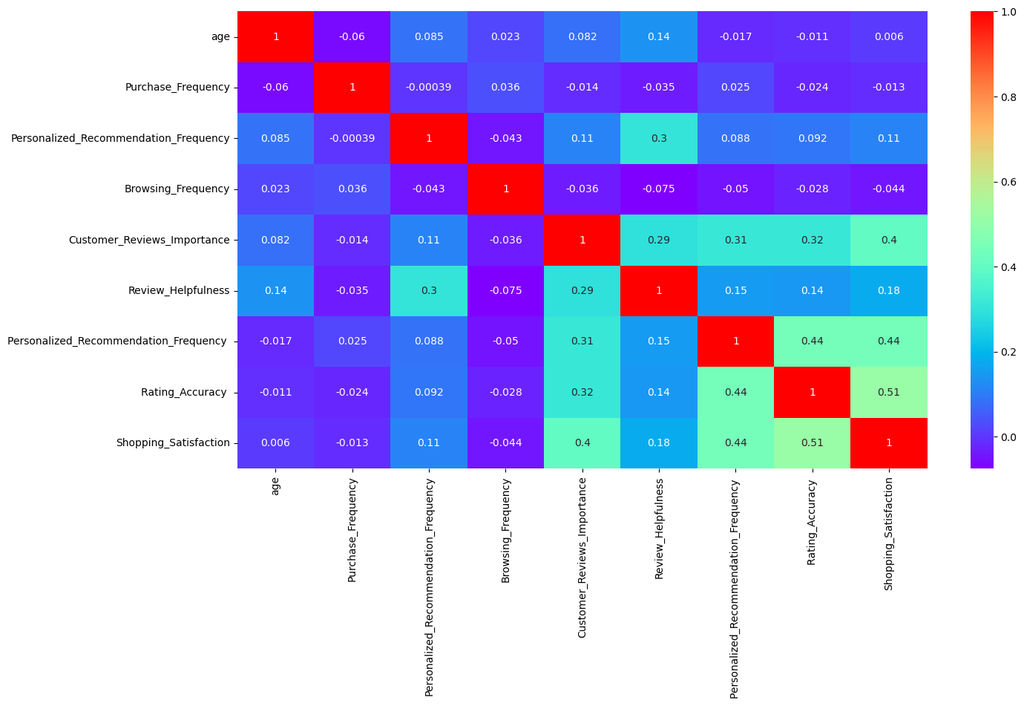

```python
plt.figure(figsize=(15,8))
sns.heatmap(data.corr(),annot=True,cmap='rainbow')
```

```python
data.head(2)
```

|  | Timestamp | age | Gender | Purchase_Frequency | Purchase_Categories | Personalized_Recommendation_Frequency | Browsing_Frequency | Product_Search_Method | Search_Result_Exploration | Customer_Reviews_Importance | ... | Saveforlater_Frequency | Review_Left | Review_Reliability | Review_Helpfulness | Personalized_Recommendation_Frequency | Recommendation_Helpfulness | Rating_Accuracy | Shopping_Satisfaction | Service_Appreciation | Improvement_Areas |
| --- | --- | --- | --- | --- | --- | --- | --- | --- | --- | --- | --- | --- | --- | --- | --- | --- | --- | --- | --- | --- | --- |
| 0 | 2023/06/04 1:28:19 PM GMT+5:30 | 23 | Female | 1 | Beauty and Personal Care | 1 | 1 | Keyword | Multiple pages | 1 | ... | Sometimes | Yes | Occasionally | 1 | 2 | Yes | 1 | 1 | Competitive prices | Reducing packaging waste |
| 1 | 2023/06/04 2:30:44 PM GMT+5:30 | 23 | Female | 4 | Clothing and Fashion | 1 | 2 | Keyword | Multiple pages | 1 | ... | Rarely | No | Heavily | 1 | 2 | Sometimes | 3 | 2 | Wide product selection | Reducing packaging waste |

2 rows × 23 columns

# Date & and time Analysis

```python
data['Timestamp']= pd.to_datetime(data['Timestamp'])
```

```python
data['year']=data['Timestamp'].dt.year
```

```python
data
```

|  | Timestamp | age | Gender | Purchase_Frequency | Purchase_Categories | Personalized_Recommendation_Frequency | Browsing_Frequency | Product_Search_Method | Search_Result_Exploration | Customer_Reviews_Importance | ... | Review_Left | Review_Reliability | Review_Helpfulness | Personalized_Recommendation_Frequency | Recommendation_Helpfulness | Rating_Accuracy | Shopping_Satisfaction | Service_Appreciation | Improvement_Areas | year |
| --- | --- | --- | --- | --- | --- | --- | --- | --- | --- | --- | --- | --- | --- | --- | --- | --- | --- | --- | --- | --- | --- |
| 0 | 2023-06-04 13:28:19-05:30 | 23 | Female | 1 | Beauty and Personal Care | 1 | 1 | Keyword | Multiple pages | 1 | ... | Yes | Occasionally | 1 | 2 | Yes | 1 | 1 | Competitive prices | Reducing packaging waste | 2023 |
| 1 | 2023-06-04 14:30:44-05:30 | 23 | Female | 4 | Clothing and Fashion | 1 | 2 | Keyword | Multiple pages | 1 | ... | No | Heavily | 1 | 2 | Sometimes | 3 | 2 | Wide product selection | Reducing packaging waste | 2023 |
| 2 | 2023-06-04 17:04:56-05:30 | 24 | Prefer not to say | 1 | Groceries and Gourmet Food;Clothing and Fashion | 2 | 2 | Keyword | Multiple pages | 2 | ... | No | Occasionally | 2 | 4 | No | 3 | 3 | Competitive prices | Product quality and accuracy | 2023 |
| 3 | 2023-06-04 17:13:00-05:30 | 24 | Female | 4 | Beauty and Personal Care;Clothing and Fashion;... | 3 | 2 | Keyword | First page | 5 | ... | Yes | Heavily | 1 | 3 | Sometimes | 3 | 4 | Competitive prices | Product quality and accuracy | 2023 |
| 4 | 2023-06-04 17:28:06-05:30 | 22 | Female | 2 | Beauty and Personal Care;Clothing and Fashion | 1 | 2 | Filter | Multiple pages | 1 | ... | No | Heavily | 1 | 4 | Yes | 2 | 2 | Competitive prices | Product quality and accuracy | 2023 |
| ... | ... | ... | ... | ... | ... | ... | ... | ... | ... | ... | ... | ... | ... | ... | ... | ... | ... | ... | ... | ... | ... |
| 597 | 2023-06-12 16:02:02-05:30 | 23 | Female | 3 | Beauty and Personal Care | 3 | 1 | categories | Multiple pages | 4 | ... | Yes | Moderately | 3 | 3 | Sometimes | 3 | 4 | Competitive prices | Customer service responsiveness | 2023 |
| 598 | 2023-06-12 16:02:53-05:30 | 23 | Female | 3 | Clothing and Fashion | 3 | 1 | Filter | Multiple pages | 3 | ... | Yes | Heavily | 3 | 3 | Sometimes | 3 | 3 | Product recommendations | Reducing packaging waste | 2023 |
| 599 | 2023-06-12 16:03:59-05:30 | 23 | Female | 4 | Beauty and Personal Care | 3 | 1 | categories | Multiple pages | 3 | ... | Yes | Occasionally | 3 | 3 | Sometimes | 2 | 3 | Wide product selection | Product quality and accuracy | 2023 |
| 600 | 2023-06-12 21:57:20-05:30 | 23 | Female | 1 | Beauty and Personal Care;Clothing and Fashion;... | 1 | 2 | Keyword | Multiple pages | 1 | ... | No | Heavily | 1 | 2 | Yes | 2 | 2 | Wide product selection | Product quality and accuracy | 2023 |
| 601 | 2023-06-16 09:16:05-05:30 | 23 | Female | 3 | Clothing and Fashion | 3 | 4 | Keyword | Multiple pages | 3 | ... | Yes | Moderately | 3 | 3 | Sometimes | 3 | 3 | Product recommendations | Product quality and accuracy | 2023 |

600 rows × 24 columns

```python
data['year'].value_counts()
```

```
2023    600
Name: year, dtype: int64
```

```python
data['month']=data['Timestamp'].dt.month
```

```python
data['month']
```

```
0      6
1      6
2      6
3      6
4      6
      ..
597    6
598    6
599    6
600    6
601    6
Name: month, Length: 600, dtype: int64
```

```python
data['month'].value_counts()
```

```
6    600
Name: month, dtype: int64
```

```python
data['day']=data['Timestamp'].dt.day
```

```python
data['day']
```

```
0       4
1       4
2       4
3       4
4       4
       ..
597    12
598    12
599    12
600    12
601    16
Name: day, Length: 600, dtype: int64
```

```python
data['day_name']=data['Timestamp'].dt.day_name()
```

```python
data['day_name']
```

```
0      Sunday
1      Sunday
2      Sunday
3      Sunday
4      Sunday
        ...
597    Monday
598    Monday
599    Monday
600    Monday
601    Friday
Name: day_name, Length: 600, dtype: object
```

```python
data
```

|  | Timestamp | age | Gender | Purchase_Frequency | Purchase_Categories | Personalized_Recommendation_Frequency | Browsing_Frequency | Product_Search_Method | Search_Result_Exploration | Customer_Reviews_Importance | ... | Personalized_Recommendation_Frequency | Recommendation_Helpfulness | Rating_Accuracy | Shopping_Satisfaction | Service_Appreciation | Improvement_Areas | year | month | day | day_name |
| --- | --- | --- | --- | --- | --- | --- | --- | --- | --- | --- | --- | --- | --- | --- | --- | --- | --- | --- | --- | --- | --- |
| 0 | 2023-06-04 13:28:19-05:30 | 23 | Female | 1 | Beauty and Personal Care | 1 | 1 | Keyword | Multiple pages | 1 | ... | 2 | Yes | 1 | 1 | Competitive prices | Reducing packaging waste | 2023 | 6 | 4 | Sunday |
| 1 | 2023-06-04 14:30:44-05:30 | 23 | Female | 4 | Clothing and Fashion | 1 | 2 | Keyword | Multiple pages | 1 | ... | 2 | Sometimes | 3 | 2 | Wide product selection | Reducing packaging waste | 2023 | 6 | 4 | Sunday |
| 2 | 2023-06-04 17:04:56-05:30 | 24 | Prefer not to say | 1 | Groceries and Gourmet Food;Clothing and Fashion | 2 | 2 | Keyword | Multiple pages | 2 | ... | 4 | No | 3 | 3 | Competitive prices | Product quality and accuracy | 2023 | 6 | 4 | Sunday |
| 3 | 2023-06-04 17:13:00-05:30 | 24 | Female | 4 | Beauty and Personal Care;Clothing and Fashion;... | 3 | 2 | Keyword | First page | 5 | ... | 3 | Sometimes | 3 | 4 | Competitive prices | Product quality and accuracy | 2023 | 6 | 4 | Sunday |
| 4 | 2023-06-04 17:28:06-05:30 | 22 | Female | 2 | Beauty and Personal Care;Clothing and Fashion | 1 | 2 | Filter | Multiple pages | 1 | ... | 4 | Yes | 2 | 2 | Competitive prices | Product quality and accuracy | 2023 | 6 | 4 | Sunday |
| ... | ... | ... | ... | ... | ... | ... | ... | ... | ... | ... | ... | ... | ... | ... | ... | ... | ... | ... | ... | ... | ... |
| 597 | 2023-06-12 16:02:02-05:30 | 23 | Female | 3 | Beauty and Personal Care | 3 | 1 | categories | Multiple pages | 4 | ... | 3 | Sometimes | 3 | 4 | Competitive prices | Customer service responsiveness | 2023 | 6 | 12 | Monday |
| 598 | 2023-06-12 16:02:53-05:30 | 23 | Female | 3 | Clothing and Fashion | 3 | 1 | Filter | Multiple pages | 3 | ... | 3 | Sometimes | 3 | 3 | Product recommendations | Reducing packaging waste | 2023 | 6 | 12 | Monday |
| 599 | 2023-06-12 16:03:59-05:30 | 23 | Female | 4 | Beauty and Personal Care | 3 | 1 | categories | Multiple pages | 3 | ... | 3 | Sometimes | 2 | 3 | Wide product selection | Product quality and accuracy | 2023 | 6 | 12 | Monday |
| 600 | 2023-06-12 21:57:20-05:30 | 23 | Female | 1 | Beauty and Personal Care;Clothing and Fashion;... | 1 | 2 | Keyword | Multiple pages | 1 | ... | 2 | Yes | 2 | 2 | Wide product selection | Product quality and accuracy | 2023 | 6 | 12 | Monday |
| 601 | 2023-06-16 09:16:05-05:30 | 23 | Female | 3 | Clothing and Fashion | 3 | 4 | Keyword | Multiple pages | 3 | ... | 3 | Sometimes | 3 | 3 | Product recommendations | Product quality and accuracy | 2023 | 6 | 16 | Friday |

600 rows × 27 columns

```python
sunday=data[data['day_name']=='Sunday']
```

```python
hist=sunday['Purchase_Categories'].value_counts()
```

```python
hist
```

```
Clothing and Fashion                                                                                17
Beauty and Personal Care;Clothing and Fashion;Home and Kitchen                                      15
Beauty and Personal Care;Clothing and Fashion                                                        9
Beauty and Personal Care                                                                             7
Groceries and Gourmet Food;Beauty and Personal Care;Clothing and Fashion;Home and Kitchen            6
Groceries and Gourmet Food;Beauty and Personal Care;Clothing and Fashion;Home and Kitchen;others     5
Groceries and Gourmet Food;Beauty and Personal Care;Clothing and Fashion                             5
others                                                                                               4
Clothing and Fashion;Home and Kitchen;others                                                         4
Beauty and Personal Care;Home and Kitchen                                                            3
Clothing and Fashion;Home and Kitchen                                                                3
Beauty and Personal Care;Clothing and Fashion;others                                                 3
Groceries and Gourmet Food;Clothing and Fashion                                                      3
Home and Kitchen                                                                                     3
Groceries and Gourmet Food                                                                           3
Clothing and Fashion;others                                                                          2
Beauty and Personal Care;Clothing and Fashion;Home and Kitchen;others                                2
Home and Kitchen;others                                                                              2
Groceries and Gourmet Food;Beauty and Personal Care                                                  2
Groceries and Gourmet Food;Clothing and Fashion;others                                               1
Groceries and Gourmet Food;Clothing and Fashion;Home and Kitchen                                     1
Name: Purchase_Categories, dtype: int64
```

```python
data.head(2)
```

|  | Timestamp | age | Gender | Purchase_Frequency | Purchase_Categories | Personalized_Recommendation_Frequency | Browsing_Frequency | Product_Search_Method | Search_Result_Exploration | Customer_Reviews_Importance | ... | Personalized_Recommendation_Frequency | Recommendation_Helpfulness | Rating_Accuracy | Shopping_Satisfaction | Service_Appreciation | Improvement_Areas | year | month | day | day_name |
| --- | --- | --- | --- | --- | --- | --- | --- | --- | --- | --- | --- | --- | --- | --- | --- | --- | --- | --- | --- | --- | --- |
| 0 | 2023-06-04 13:28:19-05:30 | 23 | Female | 1 | Beauty and Personal Care | 1 | 1 | Keyword | Multiple pages | 1 | ... | 2 | Yes | 1 | 1 | Competitive prices | Reducing packaging waste | 2023 | 6 | 4 | Sunday |
| 1 | 2023-06-04 14:30:44-05:30 | 23 | Female | 4 | Clothing and Fashion | 1 | 2 | Keyword | Multiple pages | 1 | ... | 2 | Sometimes | 3 | 2 | Wide product selection | Reducing packaging waste | 2023 | 6 | 4 | Sunday |

2 rows × 27 columns

```python
data['Month_name']=data['Timestamp'].dt.month_name()
```

```python
data
```

|  | Timestamp | age | Gender | Purchase_Frequency | Purchase_Categories | Personalized_Recommendation_Frequency | Browsing_Frequency | Product_Search_Method | Search_Result_Exploration | Customer_Reviews_Importance | ... | Recommendation_Helpfulness | Rating_Accuracy | Shopping_Satisfaction | Service_Appreciation | Improvement_Areas | year | month | day | day_name | Month_name |
| --- | --- | --- | --- | --- | --- | --- | --- | --- | --- | --- | --- | --- | --- | --- | --- | --- | --- | --- | --- | --- | --- |
| 0 | 2023-06-04 13:28:19-05:30 | 23 | Female | 1 | Beauty and Personal Care | 1 | 1 | Keyword | Multiple pages | 1 | ... | Yes | 1 | 1 | Competitive prices | Reducing packaging waste | 2023 | 6 | 4 | Sunday | June |
| 1 | 2023-06-04 14:30:44-05:30 | 23 | Female | 4 | Clothing and Fashion | 1 | 2 | Keyword | Multiple pages | 1 | ... | Sometimes | 3 | 2 | Wide product selection | Reducing packaging waste | 2023 | 6 | 4 | Sunday | June |
| 2 | 2023-06-04 17:04:56-05:30 | 24 | Prefer not to say | 1 | Groceries and Gourmet Food;Clothing and Fashion | 2 | 2 | Keyword | Multiple pages | 2 | ... | No | 3 | 3 | Competitive prices | Product quality and accuracy | 2023 | 6 | 4 | Sunday | June |
| 3 | 2023-06-04 17:13:00-05:30 | 24 | Female | 4 | Beauty and Personal Care;Clothing and Fashion;... | 3 | 2 | Keyword | First page | 5 | ... | Sometimes | 3 | 4 | Competitive prices | Product quality and accuracy | 2023 | 6 | 4 | Sunday | June |
| 4 | 2023-06-04 17:28:06-05:30 | 22 | Female | 2 | Beauty and Personal Care;Clothing and Fashion | 1 | 2 | Filter | Multiple pages | 1 | ... | Yes | 2 | 2 | Competitive prices | Product quality and accuracy | 2023 | 6 | 4 | Sunday | June |
| ... | ... | ... | ... | ... | ... | ... | ... | ... | ... | ... | ... | ... | ... | ... | ... | ... | ... | ... | ... | ... | ... |
| 597 | 2023-06-12 16:02:02-05:30 | 23 | Female | 3 | Beauty and Personal Care | 3 | 1 | categories | Multiple pages | 4 | ... | Sometimes | 3 | 4 | Competitive prices | Customer service responsiveness | 2023 | 6 | 12 | Monday | June |
| 598 | 2023-06-12 16:02:53-05:30 | 23 | Female | 3 | Clothing and Fashion | 3 | 1 | Filter | Multiple pages | 3 | ... | Sometimes | 3 | 3 | Product recommendations | Reducing packaging waste | 2023 | 6 | 12 | Monday | June |
| 599 | 2023-06-12 16:03:59-05:30 | 23 | Female | 4 | Beauty and Personal Care | 3 | 1 | categories | Multiple pages | 3 | ... | Sometimes | 2 | 3 | Wide product selection | Product quality and accuracy | 2023 | 6 | 12 | Monday | June |
| 600 | 2023-06-12 21:57:20-05:30 | 23 | Female | 1 | Beauty and Personal Care;Clothing and Fashion;... | 1 | 2 | Keyword | Multiple pages | 1 | ... | Yes | 2 | 2 | Wide product selection | Product quality and accuracy | 2023 | 6 | 12 | Monday | June |
| 601 | 2023-06-16 09:16:05-05:30 | 23 | Female | 3 | Clothing and Fashion | 3 | 4 | Keyword | Multiple pages | 3 | ... | Sometimes | 3 | 3 | Product recommendations | Product quality and accuracy | 2023 | 6 | 16 | Friday | June |

600 rows × 28 columns

```python
data['Hour']=data['Timestamp'].dt.hour
```

```python
data
```

|  | Timestamp | age | Gender | Purchase_Frequency | Purchase_Categories | Personalized_Recommendation_Frequency | Browsing_Frequency | Product_Search_Method | Search_Result_Exploration | Customer_Reviews_Importance | ... | Rating_Accuracy | Shopping_Satisfaction | Service_Appreciation | Improvement_Areas | year | month | day | day_name | Month_name | Hour |
| --- | --- | --- | --- | --- | --- | --- | --- | --- | --- | --- | --- | --- | --- | --- | --- | --- | --- | --- | --- | --- | --- |
| 0 | 2023-06-04 13:28:19-05:30 | 23 | Female | 1 | Beauty and Personal Care | 1 | 1 | Keyword | Multiple pages | 1 | ... | 1 | 1 | Competitive prices | Reducing packaging waste | 2023 | 6 | 4 | Sunday | June | 13 |
| 1 | 2023-06-04 14:30:44-05:30 | 23 | Female | 4 | Clothing and Fashion | 1 | 2 | Keyword | Multiple pages | 1 | ... | 3 | 2 | Wide product selection | Reducing packaging waste | 2023 | 6 | 4 | Sunday | June | 14 |
| 2 | 2023-06-04 17:04:56-05:30 | 24 | Prefer not to say | 1 | Groceries and Gourmet Food;Clothing and Fashion | 2 | 2 | Keyword | Multiple pages | 2 | ... | 3 | 3 | Competitive prices | Product quality and accuracy | 2023 | 6 | 4 | Sunday | June | 17 |
| 3 | 2023-06-04 17:13:00-05:30 | 24 | Female | 4 | Beauty and Personal Care;Clothing and Fashion;... | 3 | 2 | Keyword | First page | 5 | ... | 3 | 4 | Competitive prices | Product quality and accuracy | 2023 | 6 | 4 | Sunday | June | 17 |
| 4 | 2023-06-04 17:28:06-05:30 | 22 | Female | 2 | Beauty and Personal Care;Clothing and Fashion | 1 | 2 | Filter | Multiple pages | 1 | ... | 2 | 2 | Competitive prices | Product quality and accuracy | 2023 | 6 | 4 | Sunday | June | 17 |
| ... | ... | ... | ... | ... | ... | ... | ... | ... | ... | ... | ... | ... | ... | ... | ... | ... | ... | ... | ... | ... | ... |
| 597 | 2023-06-12 16:02:02-05:30 | 23 | Female | 3 | Beauty and Personal Care | 3 | 1 | categories | Multiple pages | 4 | ... | 3 | 4 | Competitive prices | Customer service responsiveness | 2023 | 6 | 12 | Monday | June | 16 |
| 598 | 2023-06-12 16:02:53-05:30 | 23 | Female | 3 | Clothing and Fashion | 3 | 1 | Filter | Multiple pages | 3 | ... | 3 | 3 | Product recommendations | Reducing packaging waste | 2023 | 6 | 12 | Monday | June | 16 |
| 599 | 2023-06-12 16:03:59-05:30 | 23 | Female | 4 | Beauty and Personal Care | 3 | 1 | categories | Multiple pages | 3 | ... | 2 | 3 | Wide product selection | Product quality and accuracy | 2023 | 6 | 12 | Monday | June | 16 |
| 600 | 2023-06-12 21:57:20-05:30 | 23 | Female | 1 | Beauty and Personal Care;Clothing and Fashion;... | 1 | 2 | Keyword | Multiple pages | 1 | ... | 2 | 2 | Wide product selection | Product quality and accuracy | 2023 | 6 | 12 | Monday | June | 21 |
| 601 | 2023-06-16 09:16:05-05:30 | 23 | Female | 3 | Clothing and Fashion | 3 | 4 | Keyword | Multiple pages | 3 | ... | 3 | 3 | Product recommendations | Product quality and accuracy | 2023 | 6 | 16 | Friday | June | 9 |

600 rows × 29 columns

```python
new=pd.DataFrame(data[['Timestamp','Purchase_Categories','Purchase_Frequency']])
```

```python
new
```

|  | Timestamp | Purchase_Categories | Purchase_Frequency |
| --- | --- | --- | --- |
| 0 | 2023-06-04 13:28:19-05:30 | Beauty and Personal Care | 1 |
| 1 | 2023-06-04 14:30:44-05:30 | Clothing and Fashion | 4 |
| 2 | 2023-06-04 17:04:56-05:30 | Groceries and Gourmet Food;Clothing and Fashion | 1 |
| 3 | 2023-06-04 17:13:00-05:30 | Beauty and Personal Care;Clothing and Fashion;... | 4 |
| 4 | 2023-06-04 17:28:06-05:30 | Beauty and Personal Care;Clothing and Fashion | 2 |
| ... | ... | ... | ... |
| 597 | 2023-06-12 16:02:02-05:30 | Beauty and Personal Care | 3 |
| 598 | 2023-06-12 16:02:53-05:30 | Clothing and Fashion | 3 |
| 599 | 2023-06-12 16:03:59-05:30 | Beauty and Personal Care | 4 |
| 600 | 2023-06-12 21:57:20-05:30 | Beauty and Personal Care;Clothing and Fashion;... | 1 |
| 601 | 2023-06-16 09:16:05-05:30 | Clothing and Fashion | 3 |

600 rows × 3 columns

```python
new['day_name']=new['Timestamp'].dt.day_name()
```

```python
new
```

|  | Timestamp | Purchase_Categories | Purchase_Frequency | day_name |
| --- | --- | --- | --- | --- |
| 0 | 2023-06-04 13:28:19-05:30 | Beauty and Personal Care | 1 | Sunday |
| 1 | 2023-06-04 14:30:44-05:30 | Clothing and Fashion | 4 | Sunday |
| 2 | 2023-06-04 17:04:56-05:30 | Groceries and Gourmet Food;Clothing and Fashion | 1 | Sunday |
| 3 | 2023-06-04 17:13:00-05:30 | Beauty and Personal Care;Clothing and Fashion;... | 4 | Sunday |
| 4 | 2023-06-04 17:28:06-05:30 | Beauty and Personal Care;Clothing and Fashion | 2 | Sunday |
| ... | ... | ... | ... | ... |
| 597 | 2023-06-12 16:02:02-05:30 | Beauty and Personal Care | 3 | Monday |
| 598 | 2023-06-12 16:02:53-05:30 | Clothing and Fashion | 3 | Monday |
| 599 | 2023-06-12 16:03:59-05:30 | Beauty and Personal Care | 4 | Monday |
| 600 | 2023-06-12 21:57:20-05:30 | Beauty and Personal Care;Clothing and Fashion;... | 1 | Monday |
| 601 | 2023-06-16 09:16:05-05:30 | Clothing and Fashion | 3 | Friday |

600 rows × 4 columns

```python
new['day_name'].value_counts()
```

```
Thursday     118
Wednesday    112
Sunday       100
Monday        98
Tuesday       86
Friday        82
Saturday       4
Name: day_name, dtype: int64
```

```python
new.groupby('day_name')['Purchase_Frequency'].count()
```

```
day_name
Friday        82
Monday        98
Saturday       4
Sunday       100
Thursday     118
Tuesday       86
Wednesday    112
Name: Purchase_Frequency, dtype: int64
```

```python
sunday=new[new['day_name']=='Sunday']
```

```python
sunday
```

|  | Timestamp | Purchase_Categories | Purchase_Frequency | day_name |
| --- | --- | --- | --- | --- |
| 0 | 2023-06-04 13:28:19-05:30 | Beauty and Personal Care | 1 | Sunday |
| 1 | 2023-06-04 14:30:44-05:30 | Clothing and Fashion | 4 | Sunday |
| 2 | 2023-06-04 17:04:56-05:30 | Groceries and Gourmet Food;Clothing and Fashion | 1 | Sunday |
| 3 | 2023-06-04 17:13:00-05:30 | Beauty and Personal Care;Clothing and Fashion;... | 4 | Sunday |
| 4 | 2023-06-04 17:28:06-05:30 | Beauty and Personal Care;Clothing and Fashion | 2 | Sunday |
| ... | ... | ... | ... | ... |
| 560 | 2023-06-11 23:26:21-05:30 | Groceries and Gourmet Food;Beauty and Personal... | 5 | Sunday |
| 561 | 2023-06-11 23:26:54-05:30 | Groceries and Gourmet Food;Beauty and Personal... | 1 | Sunday |
| 562 | 2023-06-11 23:27:25-05:30 | Clothing and Fashion | 3 | Sunday |
| 563 | 2023-06-11 23:27:55-05:30 | Clothing and Fashion | 2 | Sunday |
| 564 | 2023-06-11 23:28:26-05:30 | Groceries and Gourmet Food;Clothing and Fashion | 3 | Sunday |

100 rows × 4 columns

```python
sunday['Purchase_Frequency'].value_counts() #Few times a month':1,'Less than once a month':2,'Once a week':3,'Once a month':4,'Multiple times a week':5})
```

```
1    40
2    25
4    18
5    10
3     7
Name: Purchase_Frequency, dtype: int64
```

```python
sunday['Purchase_Categories'].value_counts()
```

```
Clothing and Fashion                                                                                17
Beauty and Personal Care;Clothing and Fashion;Home and Kitchen                                      15
Beauty and Personal Care;Clothing and Fashion                                                        9
Beauty and Personal Care                                                                             7
Groceries and Gourmet Food;Beauty and Personal Care;Clothing and Fashion;Home and Kitchen            6
Groceries and Gourmet Food;Beauty and Personal Care;Clothing and Fashion;Home and Kitchen;others     5
Groceries and Gourmet Food;Beauty and Personal Care;Clothing and Fashion                             5
others                                                                                               4
Clothing and Fashion;Home and Kitchen;others                                                         4
Beauty and Personal Care;Home and Kitchen                                                            3
Clothing and Fashion;Home and Kitchen                                                                3
Beauty and Personal Care;Clothing and Fashion;others                                                 3
Groceries and Gourmet Food;Clothing and Fashion                                                      3
Home and Kitchen                                                                                     3
Groceries and Gourmet Food                                                                           3
Clothing and Fashion;others                                                                          2
Beauty and Personal Care;Clothing and Fashion;Home and Kitchen;others                                2
Home and Kitchen;others                                                                              2
Groceries and Gourmet Food;Beauty and Personal Care                                                  2
Groceries and Gourmet Food;Clothing and Fashion;others                                               1
Groceries and Gourmet Food;Clothing and Fashion;Home and Kitchen                                     1
Name: Purchase_Categories, dtype: int64
```

[output not shown]

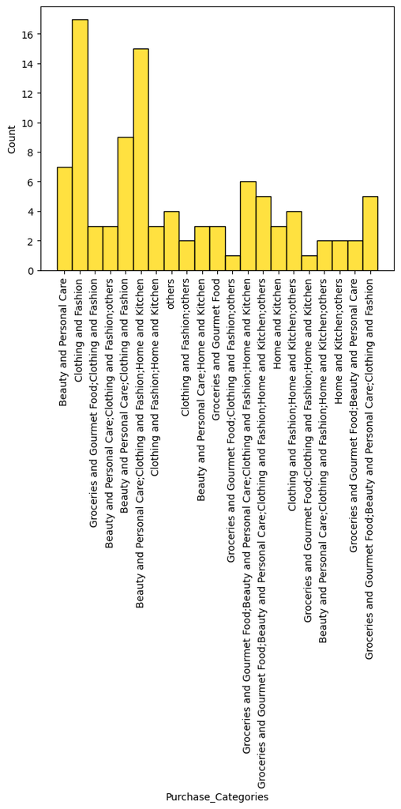

```python
sns.histplot(sunday['Purchase_Categories'],color='gold')
plt.xticks(rotation=90)
#in Sunday overall clothing and fashion items is high
```

```python
new
```

|  | Timestamp | Purchase_Categories | Purchase_Frequency | day_name |
| --- | --- | --- | --- | --- |
| 0 | 2023-06-04 13:28:19-05:30 | Beauty and Personal Care | 1 | Sunday |
| 1 | 2023-06-04 14:30:44-05:30 | Clothing and Fashion | 4 | Sunday |
| 2 | 2023-06-04 17:04:56-05:30 | Groceries and Gourmet Food;Clothing and Fashion | 1 | Sunday |
| 3 | 2023-06-04 17:13:00-05:30 | Beauty and Personal Care;Clothing and Fashion;... | 4 | Sunday |
| 4 | 2023-06-04 17:28:06-05:30 | Beauty and Personal Care;Clothing and Fashion | 2 | Sunday |
| ... | ... | ... | ... | ... |
| 597 | 2023-06-12 16:02:02-05:30 | Beauty and Personal Care | 3 | Monday |
| 598 | 2023-06-12 16:02:53-05:30 | Clothing and Fashion | 3 | Monday |
| 599 | 2023-06-12 16:03:59-05:30 | Beauty and Personal Care | 4 | Monday |
| 600 | 2023-06-12 21:57:20-05:30 | Beauty and Personal Care;Clothing and Fashion;... | 1 | Monday |
| 601 | 2023-06-16 09:16:05-05:30 | Clothing and Fashion | 3 | Friday |

600 rows × 4 columns

```python
monday=new[new['day_name']=='Monday']
```

```python
monday
```

|  | Timestamp | Purchase_Categories | Purchase_Frequency | day_name |
| --- | --- | --- | --- | --- |
| 39 | 2023-06-05 00:02:56-05:30 | Clothing and Fashion | 1 | Monday |
| 40 | 2023-06-05 00:05:20-05:30 | others | 2 | Monday |
| 41 | 2023-06-05 00:36:02-05:30 | others | 2 | Monday |
| 42 | 2023-06-05 00:37:54-05:30 | Home and Kitchen | 4 | Monday |
| 43 | 2023-06-05 00:39:14-05:30 | Beauty and Personal Care;others | 2 | Monday |
| ... | ... | ... | ... | ... |
| 596 | 2023-06-12 16:00:56-05:30 | Beauty and Personal Care | 3 | Monday |
| 597 | 2023-06-12 16:02:02-05:30 | Beauty and Personal Care | 3 | Monday |
| 598 | 2023-06-12 16:02:53-05:30 | Clothing and Fashion | 3 | Monday |
| 599 | 2023-06-12 16:03:59-05:30 | Beauty and Personal Care | 4 | Monday |
| 600 | 2023-06-12 21:57:20-05:30 | Beauty and Personal Care;Clothing and Fashion;... | 1 | Monday |

98 rows × 4 columns

[output not shown]

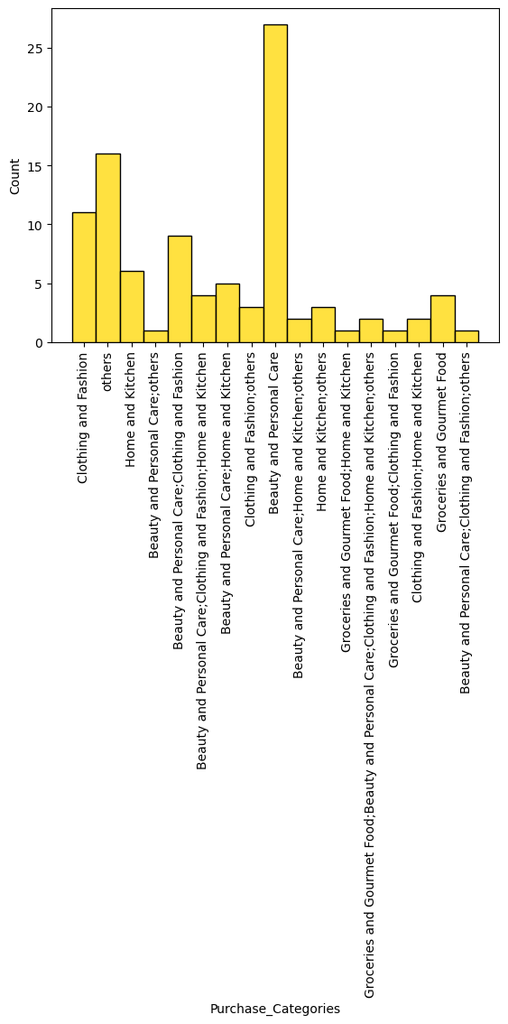

```python
sns.histplot(monday['Purchase_Categories'],color='gold')
plt.xticks(rotation=90)
#in monday overall beauty care items is high
```

```python
data
```

|  | Timestamp | age | Gender | Purchase_Frequency | Purchase_Categories | Personalized_Recommendation_Frequency | Browsing_Frequency | Product_Search_Method | Search_Result_Exploration | Customer_Reviews_Importance | ... | Rating_Accuracy | Shopping_Satisfaction | Service_Appreciation | Improvement_Areas | year | month | day | day_name | Month_name | Hour |
| --- | --- | --- | --- | --- | --- | --- | --- | --- | --- | --- | --- | --- | --- | --- | --- | --- | --- | --- | --- | --- | --- |
| 0 | 2023-06-04 13:28:19-05:30 | 23 | Female | 1 | Beauty and Personal Care | 1 | 1 | Keyword | Multiple pages | 1 | ... | 1 | 1 | Competitive prices | Reducing packaging waste | 2023 | 6 | 4 | Sunday | June | 13 |
| 1 | 2023-06-04 14:30:44-05:30 | 23 | Female | 4 | Clothing and Fashion | 1 | 2 | Keyword | Multiple pages | 1 | ... | 3 | 2 | Wide product selection | Reducing packaging waste | 2023 | 6 | 4 | Sunday | June | 14 |
| 2 | 2023-06-04 17:04:56-05:30 | 24 | Prefer not to say | 1 | Groceries and Gourmet Food;Clothing and Fashion | 2 | 2 | Keyword | Multiple pages | 2 | ... | 3 | 3 | Competitive prices | Product quality and accuracy | 2023 | 6 | 4 | Sunday | June | 17 |
| 3 | 2023-06-04 17:13:00-05:30 | 24 | Female | 4 | Beauty and Personal Care;Clothing and Fashion;... | 3 | 2 | Keyword | First page | 5 | ... | 3 | 4 | Competitive prices | Product quality and accuracy | 2023 | 6 | 4 | Sunday | June | 17 |
| 4 | 2023-06-04 17:28:06-05:30 | 22 | Female | 2 | Beauty and Personal Care;Clothing and Fashion | 1 | 2 | Filter | Multiple pages | 1 | ... | 2 | 2 | Competitive prices | Product quality and accuracy | 2023 | 6 | 4 | Sunday | June | 17 |
| ... | ... | ... | ... | ... | ... | ... | ... | ... | ... | ... | ... | ... | ... | ... | ... | ... | ... | ... | ... | ... | ... |
| 597 | 2023-06-12 16:02:02-05:30 | 23 | Female | 3 | Beauty and Personal Care | 3 | 1 | categories | Multiple pages | 4 | ... | 3 | 4 | Competitive prices | Customer service responsiveness | 2023 | 6 | 12 | Monday | June | 16 |
| 598 | 2023-06-12 16:02:53-05:30 | 23 | Female | 3 | Clothing and Fashion | 3 | 1 | Filter | Multiple pages | 3 | ... | 3 | 3 | Product recommendations | Reducing packaging waste | 2023 | 6 | 12 | Monday | June | 16 |
| 599 | 2023-06-12 16:03:59-05:30 | 23 | Female | 4 | Beauty and Personal Care | 3 | 1 | categories | Multiple pages | 3 | ... | 2 | 3 | Wide product selection | Product quality and accuracy | 2023 | 6 | 12 | Monday | June | 16 |
| 600 | 2023-06-12 21:57:20-05:30 | 23 | Female | 1 | Beauty and Personal Care;Clothing and Fashion;... | 1 | 2 | Keyword | Multiple pages | 1 | ... | 2 | 2 | Wide product selection | Product quality and accuracy | 2023 | 6 | 12 | Monday | June | 21 |
| 601 | 2023-06-16 09:16:05-05:30 | 23 | Female | 3 | Clothing and Fashion | 3 | 4 | Keyword | Multiple pages | 3 | ... | 3 | 3 | Product recommendations | Product quality and accuracy | 2023 | 6 | 16 | Friday | June | 9 |

600 rows × 29 columns

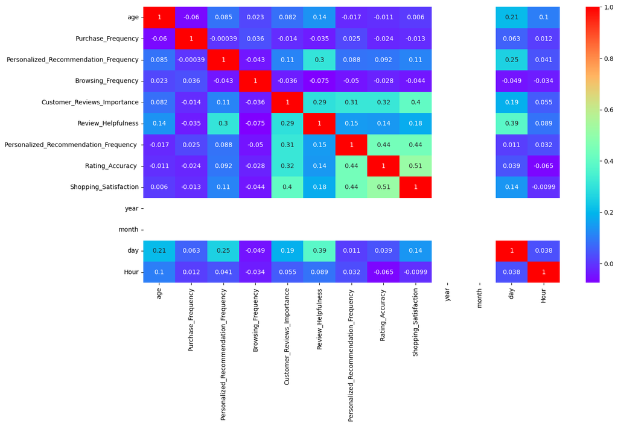

```python
plt.figure(figsize=(15,8))
sns.heatmap(data.corr(),annot=True,cmap='rainbow')
```

```python
data['Shopping_Satisfaction'].value_counts()
```

```
3    208
2    193
1    115
4     67
5     17
Name: Shopping_Satisfaction, dtype: int64
```

```python
data.info()
```

```
<class 'pandas.core.frame.DataFrame'>
Int64Index: 600 entries, 0 to 601
Data columns (total 29 columns):
 #   Column                                  Non-Null Count  Dtype
---  ------                                  --------------  -----
 0   Timestamp                               600 non-null    datetime64[ns, pytz.FixedOffset(-330)]
 1   age                                     600 non-null    int64
 2   Gender                                  600 non-null    object
 3   Purchase_Frequency                      600 non-null    int64
 4   Purchase_Categories                     600 non-null    object
 5   Personalized_Recommendation_Frequency   600 non-null    int64
 6   Browsing_Frequency                      600 non-null    int64
 7   Product_Search_Method                   600 non-null    object
 8   Search_Result_Exploration               600 non-null    object
 9   Customer_Reviews_Importance             600 non-null    int64
```

[output cut: 21 more lines]

```python
M_data = pd.DataFrame(data['Purchase_Frequency'], index=data['day'])
```

```python
M_data
```

| day | Purchase_Frequency |
| --- | --- |
| 4 | 2 |
| 4 | 2 |
| 4 | 2 |
| 4 | 2 |
| 4 | 2 |
| ... | ... |
| 12 | 2 |
| 12 | 2 |
| 12 | 2 |
| 12 | 2 |
| 16 | 1 |

600 rows × 1 columns

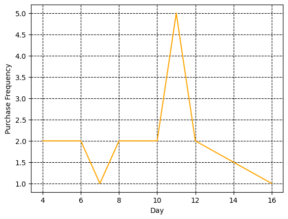

```python
plt.plot(M_data,color='Orange')
plt.xlabel('Day')
plt.ylabel('Purchase Frequency')
plt.grid(True,linestyle='--',color='Black')
```